# R4BD_Enron_project_V2

Marie Winter

2025-04-19

# Introduction

## A little history about Enron company

Enron is a natural-gas-transmission company founded in 1985 in the US. In 1990’s the US congress adopt a series of law to deregulate the sale of natural gas. This makes Enron loosing it’s exclusivity right on the natural gas pipeline. At this time Jeffrey Skilling, who was initially a consultant and later became the company’s chief operating officer, transformed Enron into a trader energy derivative to be an intermediary between natural-gas producers and their customers. Soon after that, Enron become a leader in this market and makes huge profit on its trade. This golden age for the company allow them to recruit Andrew Fastow who quickly became the chief financial officer. Moreover, they diversify their activity to include electricity, coal, paper, and steel. Perhaps, success have is limit and in late 90’s the company profit start to shrank… The pressure from shareholders, company executives began to rely on dubious accounting practices. Especially they used the “market-to-market accounting” which allowed the company to write unrealized future gain from some trading contract into current income statement, thus giving the illusion of higher current profits. In August, 2001 some people at the head of the company start to worry about a possible accounting scandals due to this practice. In October, 2001 the Securities and Exchange Commission began investigating the transactions of Enron. This was the starting event who lead the company to the bankruptcy which really start in December, 2001.

Source [Britannica Enron scandal](https://www.britannica.com/event/Enron-scandal).

## Project aims

The principal aim of this project is to explore the Enron’s email data set for extracting insight about the fiscal fraud investigation and bankruptcy of the company in 2001. For that have 3 data sets:

- the employee list with their email address
- the emails exchange from 1999 to 2002
- the recipients of each emails (to, cc, bcc).

The different insight will are available into a shiny apps.

For that project we used several libraries listed here: For data exploration, analysis and visualization:

- [tidyverse](https://www.tidyverse.org/packages/)
- [circlize](https://cran.r-project.org/web/packages/circlize/index.html)
- [ggpubr](https://rpkgs.datanovia.com/ggpubr/)
- [patchwork](https://patchwork.data-imaginist.com/index.html)
- ggbreak
- [gridExtra](https://cran.r-project.org/web/packages/gridExtra/index.html)
- [grid](https://bookdown.org/rdpeng/RProgDA/the-grid-package.html)

*[gtable](https://cran.r-project.org/web/packages/gtable/index.html)

To display the result into the Rmarkdown report:

- [knitr](https://cran.r-project.org/web/packages/knitr/index.html)

To create the shiny apps:

- [shiny](https://shiny.posit.co/r/getstarted/shiny-basics/lesson1/)

```r
#library
library(tidyverse)
library(circlize)
library(ggpubr)
library(patchwork)
library(gridExtra)
library(grid)
library(gtable)
library(ggbreak)
library(knitr)
library(shiny)

#dataset
load(file = "C:/Users/marie/Documents/DSTI_Cours/R_big_Data/Exam/Enron_project/Enron.Rdata")
```

```r
#function to extract the legend from each plot
get_legend <- function(p, #the plot need to be arrange on a same layout and shared the same legend
                       nrow=2 #the number of row where the legend will be display, by default 2
                       ){

  #override the guides to control the number of rows in legend
  p_wrapped <- p + guides(
    #allow to control how the legend is arrange
    fill = guide_legend(nrow = nrow, byrow = TRUE),
    color = guide_legend(nrow = nrow, byrow = TRUE))

  #generate a temporary table with the graphical component
  temp <- ggplotGrob(p_wrapped)

  #extract the legend, guide-box, and store it in a list
  legend <- temp$grobs[which(sapply(temp$grobs, function(x) x$name) == "guide-box")]

  #return only one legend not the list of them
  return(legend[[1]])
}
```

# Data exploring and cleaning

## First look at the data

The aim of this part is to see :

- which kind of data the different table contains
- the existence of missing value and how to handle them

### employee dataset

Description of the data set variables and dimension:

```r
dim_employee <- dim(employeelist)

summary(employeelist)
```

```
##       eid          firstName           lastName           Email_id
##  Min.   :  1.00   Length:149         Length:149         Length:149
##  1st Qu.: 38.00   Class :character   Class :character   Class :character
##  Median : 75.00   Mode  :character   Mode  :character   Mode  :character
##  Mean   : 75.07
##  3rd Qu.:112.00
##  Max.   :150.00
##
##     Email2             Email3             EMail4             folder
##  Length:149         Length:149         Length:149         Length:149
##  Class :character   Class :character   Class :character   Class :character
##  Mode  :character   Mode  :character   Mode  :character   Mode  :character
##
##
##
##
##             status
##  Employee      :41
##  N/A           :31
##  Vice President:23
##  Director      :14
##  Manager       :14
##  (Other)       :25
##  NA's          : 1
```

This data set contain 149 rows and 9 columns.

This data set contains employee ID (eid), the first and last name of the employee as well as their status, the email addresses for each employee, and the folder where their email are stored. In the status variable there exist missing value’s identify by R (NA) but also putting directly in the data by the set owner which are write N/A. The eid variable is identify has type numeric, status is associate with a factor type and the other variable are character type.

Display of some observations in the data frame:

```r
kable(employeelist[1:10, ])
```

| eid | firstName | lastName | Email_id | Email2 | Email3 | EMail4 | folder | status |
| --- | --- | --- | --- | --- | --- | --- | --- | --- |
| 13 | Marie | Heard | marie.heard@enron.com |  |  |  | heard-m | NA |
| 6 | Mark | Taylor | mark.e.taylor@enron.com | mark.taylor@enron.com | e.taylor@enron.com |  | taylor-m | Employee |
| 19 | Lindy | Donoho | lindy.donoho@enron.com | ldonoho@enron.com |  |  | donoho-l | Employee |
| 115 | Lisa | Gang | lisa.gang@enron.com |  |  |  | gang-l | N/A |
| 129 | Jeffrey | Skilling | jeff.skilling@enron.com | jeffrey.skilling@enron.com |  |  | skilling-j | CEO |
| 18 | Lynn | Blair | lynn.blair@enron.com | lynnblair@enron.com |  |  | blair-l | Director |
| 33 | Kim | Ward | kim.ward@enron.com | kward@enron.com |  |  | ward-k | N/A |
| 149 | Kate | Symes | kate.symes@enron.com | ksymes@enron.com |  |  | symes-k | Employee |
| 52 | Kay | Mann | kay.mann@enron.com |  |  |  | mann-k | Employee |
| 21 | Keith | Holst | keith.holst@enron.com | kholst@enron.com |  |  | holst-k | Director |

By looking at the head of the data, we observed that eid is associate to numeric data type but the more adapted type seems to be factor because it is an ID for employee. In addition, the variables Email2, Email3, EMail4 contain a lot of blank.

To investigate the blank we temporary change the datatype of those variables from character to factor to see what kind of result we return for the blank observation.

```r
kable(employeelist %>% transform(
  Email2 = as.factor(Email2),
  Email3 = as.factor(Email3),
  EMail4 = as.factor(EMail4)
) %>% summary())
```

|  | eid | firstName | lastName | Email_id | Email2 | Email3 | EMail4 | folder | status |
| --- | --- | --- | --- | --- | --- | --- | --- | --- | --- |
|  | Min. : 1.00 | Length:149 | Length:149 | Length:149 | :52 | :100 | :147 | Length:149 | Employee :41 |
|  | 1st Qu.: 38.00 | Class :character | Class :character | Class :character | a..shankman@enron.com : 1 | a..martin@enron.com : 1 | j..kean@enron.com : 1 | Class :character | N/A :31 |
|  | Median : 75.00 | Mode :character | Mode :character | Mode :character | andrew.lewis@enron.com: 1 | andrew.h.lewis@enron.com: 1 | peter.f.keavey@enron.com: 1 | Mode :character | Vice President:23 |
|  | Mean : 75.07 | NA | NA | NA | azipper@enron.com : 1 | c.germany@enron.com : 1 | NA | NA | Director :14 |
|  | 3rd Qu.:112.00 | NA | NA | NA | b..sanders@enron.com : 1 | carol.stclair@enron.com : 1 | NA | NA | Manager :14 |
|  | Max. :150.00 | NA | NA | NA | barbo@enron.com : 1 | dana_davis@enron.com : 1 | NA | NA | (Other) :25 |
|  | NA | NA | NA | NA | (Other) :92 | (Other) : 44 | NA | NA | NA’s : 1 |

We can see that, in the Email2, Email3, and EMail4 variable don’t have missing value but they are blank character. In the Email3 and EMail4 more than the half of the value are blank, maybe those variable aren’t very helpful for the analysis. In the variable status the NA are differently declared where we have 31 values with N/A and only 1 NA. For that variable we will need to replace the N/A by real NA values to homogenized the data.

### message data set

Description of the data set variables and dimension:

```r
dim_message <- dim(message)

kable(summary(message))
```

|  | mid | sender | date | message_id | subject |
| --- | --- | --- | --- | --- | --- |
|  | Min. : 52 | jeff.dasovich@enron.com : 6273 | Min. :0001-05-30 | 10000282.1075847198841.JavaMail.evans@thyme: 1 | Length:252759 |
|  | 1st Qu.: 88565 | j.kaminski@enron.com : 5838 | 1st Qu.:2000-12-01 | 10000478.1075841161605.JavaMail.evans@thyme: 1 | Class :character |
|  | Median :186421 | kay.mann@enron.com : 5100 | Median :2001-05-21 | 1000097.1075860055721.JavaMail.evans@thyme : 1 | Mode :character |
|  | Mean :190260 | sara.shackleton@enron.com: 4797 | Mean :1999-04-15 | 1000099.1075858574579.JavaMail.evans@thyme : 1 | NA |
|  | 3rd Qu.:279962 | tana.jones@enron.com : 4437 | 3rd Qu.:2001-10-25 | 1000115.1075852075775.JavaMail.evans@thyme : 1 | NA |
|  | Max. :404927 | chris.germany@enron.com : 3686 | Max. :2044-01-04 | 1000122.1075858816233.JavaMail.evans@thyme : 1 | NA |
|  | NA | (Other) :222628 | NA | (Other) :252753 | NA |

This data set contain 252759 rows and 5 columns.

Here we observed that, the mid and date variables identify as a numeric, the variables sender and message_id are attached to factor data type, and the variable subject is character data type.

Display of some observations in the data frame:

```r
kable(message[1:10, ])
```

| mid | sender | date | message_id | subject |
| --- | --- | --- | --- | --- |
| 52 | press.release@enron.com | 2000-01-21 | 12435833.1075863606729.JavaMail.evans@thyme | ENRON HOSTS ANNUAL ANALYST CONFERENCE PROVIDES BUSINESS OVERVIEW AND GOALS FOR 2000 |
| 53 | office.chairman@enron.com | 2000-01-24 | 29664079.1075863606676.JavaMail.evans@thyme | Over $50 – You made it happen! |
| 54 | office.chairman@enron.com | 2000-01-24 | 15300605.1075863606629.JavaMail.evans@thyme | Over $50 – You made it happen! |
| 55 | press.release@enron.com | 2000-02-02 | 10522232.1075863606538.JavaMail.evans@thyme | ROAD-SHOW.COM Q4i.COM CHOOSE ENRON TO DELIVER FINANCIAL WEB CONTENT |
| 56 | office.chairman@enron.com | 2000-02-07 | 16056123.1075863606515.JavaMail.evans@thyme | Fortune Most Admired Ranking |
| 57 | foothi19@idt.net | 2000-08-25 | 31680362.1075863730221.JavaMail.evans@thyme | WPTF Friday Credo Veritas Burrito |
| 58 | enron.announcements@enron.com | 2000-06-21 | 25532011.1075863606453.JavaMail.evans@thyme | SAP ID - Here it is!!!!! |
| 59 | christopher.calger@enron.com | 2000-06-27 | 23318125.1075863606431.JavaMail.evans@thyme | Set of Graphs |
| 60 | christian.yoder@enron.com | 2000-07-25 | 25889429.1075863606409.JavaMail.evans@thyme | Block Forward Financial Trades |
| 61 | carla.hoffman@enron.com | 2000-07-27 | 9486701.1075863606387.JavaMail.evans@thyme | Block forwards |

By looking at the head of the data we observed that, the mid don’t look like numeric data but more has identifier like the eid variable in the employeelist table. In the data frame the date variable is associate to a date type. More over it seems that the observation in the subject variable are repeat several time suggesting they aren’t individual string but more a categorical variable.

Because the description seems to treat the variable date as a numeric type but the observation look like real date in the data display above we check with the class() function if R treat it correctly by evaluating if his data type is Date:

```r
class(message$date) == "Date"
```

```
## [1] TRUE
```

The result confirm us R treat the date variable in the good data type meaning Date type. For this variable it is not necessary to adapt the data type.

In the date variable the min and max values return are strange date. In the introduction we saw that the data cover the period between 1999 and 2002 and those value aren’t in that period.

To understand what is those values we filter the table to get the year is less than 1999 or more than 2002:

```r
kable(message %>%
  select(date) %>% #keep the date variable
  mutate(year = format(date,"%Y")) %>% #extract the year from the date
  filter((year < 1999) | (year > 2002)) %>% #keep the value below and after the study's period
  group_by(year) %>% count()) #count the number of rows per date out of the study's period
```

| year | n |
| --- | --- |
| 0001 | 205 |
| 0002 | 53 |
| 1979 | 6 |
| 1997 | 1 |
| 1998 | 85 |
| 2004 | 53 |
| 2007 | 1 |
| 2020 | 2 |
| 2043 | 1 |
| 2044 | 3 |

The variable mid and message_id could be redundancy. To verify that we will count the number of distinct value for both variable to see if a mid could be attached to several message_id.

```r
kable(message%>% select(mid, message_id) %>% #select only the variable we need.
  transform(mid = as.factor(mid)) %>% #transform the mid into factor data type.
  group_by(message_id) %>%
  count(mid) %>% #count the number of mid per message_id group, create a n variable with the result.
  filter(n != 1)) #filter to get the rows with a value different than 1.
```

| message_id | mid | n |
| --- | --- | --- |

This shown that, each message_id is attached to one and only one mid and confirm to us the redundancy of the 2 variables in the data frame. To lighten the data we can choose one of them to be kept in the dataframe for the analysis.

As we saw in the table header me have email address of the email’s sender in the sender variable. Those email address are also in the employeelist where it as for most of the employee their status in the company but there are split into 4 different variable. In addition, the variable Email3 and EMail4 contain a lot of blank value. To see how we will can merge the two table we look at the correspondance between the 2 tables for the email address.

```r
#prepared table to only check which email address in the Email_ID are also in the sender
employee_merge1 <- employeelist %>% mutate(sender = Email_id) %>% select(sender)
employee_merge2 <- employeelist %>% mutate(sender = Email2) %>% select(sender)
employee_merge3 <- employeelist %>% mutate(sender = Email3) %>% select(sender)
employee_merge4 <- employeelist %>% mutate(sender = EMail4) %>% select(sender)

#to do the join only with the sender variable
message_merge <- message %>% select(sender)
```

```r
#first between the sender in the message table and the Email_id in the employeelist
EmailID_sender1 <- inner_join(message_merge, employee_merge1, by = "sender")

EmailID_sender1 %>% count()
```

```
##        n
## 1 104766
```

```r
#between the sender in the message table and the Email2 in the employeelist
EmailID_sender2 <- inner_join(message_merge, employee_merge2, by = "sender")

EmailID_sender2 %>% count()
```

```
##   n
## 1 0
```

```r
#between the sender in the message table and the Email3 in the employeelist
EmailID_sender3 <- inner_join(message_merge, employee_merge3, by = "sender")

EmailID_sender3 %>% count()
```

```
##      n
## 1 1170
```

```r
#between the sender in the message table and the EMail4 in the employeelist
EmailID_sender4 <- inner_join(message_merge, employee_merge4, by = "sender")

EmailID_sender4 %>% count()
```

```
##   n
## 1 0
```

By using the inner_join we can see that, in the employeelist table only the variable Email_id and Email3 have email address which are also in the sender variable of the message table. If we want to get the status of the employee status attached to the sender email address we need to do the merge with those variable.

### recipient info data set

Description of the data set variables and dimension:

```r
dim_recipient <- dim(recipientinfo)

summary(recipientinfo)
```

```
##       rid               mid         rtype
##  Min.   :     67   Min.   :    52   BCC: 253713
##  1st Qu.: 718289   1st Qu.:105438   CC : 253735
##  Median :1515296   Median :198263   TO :1556994
##  Mean   :1543862   Mean   :196168
##  3rd Qu.:2309682   3rd Qu.:280673
##  Max.   :3242063   Max.   :404927
##
##                        rvalue
##  no.address@enron.com     :  19198
##  jeff.dasovich@enron.com  :  11137
##  richard.shapiro@enron.com:  11015
##  steven.j.kean@enron.com  :  10873
##  james.d.steffes@enron.com:  10615
##  tana.jones@enron.com     :   9781
##  (Other)                  :1991823
```

This data set contain 2064442 rows and 4 columns. The summary of the data reveal that, the rid and mid are consider as numeric variable by R and the variables rtype and rvalue are consider as factor data type.

Display of some observations in the data frame:

| rid | mid | rtype | rvalue |
| --- | --- | --- | --- |
| 67 | 52 | TO | all.worldwide@enron.com |
| 68 | 53 | TO | all.downtown@enron.com |
| 69 | 54 | TO | all.enron-worldwide@enron.com |
| 70 | 55 | TO | all.worldwide@enron.com |
| 71 | 56 | TO | all_enron_north.america@enron.com |
| 72 | 56 | TO | ec.communications@enron.com |
| 73 | 57 | TO | charlotte@wptf.org |
| 74 | 58 | TO | sap.mailout@enron.com |
| 75 | 59 | TO | robert.badeer@enron.com |
| 76 | 60 | TO | tim.belden@enron.com |

By looking at the head of this dataset we can see that rid and mid are identifier, with the result return by the summary function we need to transform those variables into factor data for having in the good type. Also, the mid variable is a foreign key allowed to link this table with the message table. Binding together this 2 table will allow us to have the sender and the receiver of the email as well as which type of receiver (direct with the to or “indirect” with the CC and BCC). The last variable rvalue is the email address of the receiver which can be general (*e.g.,* all.worldwide@enron.com, see in the head of the table) or specific to a person (*e.g.,* jeff.dasovich@enron.com, see as the top specific receiver in the summary of that table). The specific email address in the rsender variable can be find in the email addresses in the employeelist variable related to the email address of each employee to get their status in the company. We proceed as with the message table.

```r
#prepared table to only check which email address in the Email_ID are also in the sender
employee_merge1 <- employeelist %>% mutate(rvalue = Email_id) %>% select(rvalue)
employee_merge2 <- employeelist %>% mutate(rvalue = Email2) %>% select(rvalue)
employee_merge3 <- employeelist %>% mutate(rvalue = Email3) %>% select(rvalue)
employee_merge4 <- employeelist %>% mutate(rvalue = EMail4) %>% select(rvalue)

#to do the join only with the sender variable
recipient_merge <- recipientinfo %>% select(rvalue)
```

```r
#first between the rvalue in the recipient table and the Email_id in the employeelist
EmailID_recipient1 <- inner_join(recipient_merge, employee_merge1, by = "rvalue")

EmailID_recipient1 %>% count()
```

```
##        n
## 1 361234
```

```r
# between the rvalue in the recipient table and the Email2 in the employeelist
EmailID_recipient2 <- inner_join(recipient_merge, employee_merge2, by = "rvalue")

EmailID_recipient2 %>% count()
```

```
##   n
## 1 0
```

```r
#between the rvalue in the recipient table and the Email3 in the employeelist
EmailID_recipient3 <- inner_join(recipient_merge, employee_merge3, by = "rvalue")

EmailID_recipient3 %>% count()
```

```
##      n
## 1 2382
```

```r
#first between the rvalue in the recipient table and the EMail4 in the employeelist
EmailID_recipient4 <- inner_join(recipient_merge, employee_merge4, by = "rvalue")

EmailID_recipient4 %>% count()
```

```
##   n
## 1 0
```

Like in the message table, we only have match between the rvalue and the Email_id and Email3 variable.

### reference info data set

Description of the data set variables and dimension:

```r
dim_reference <- dim(referenceinfo)

summary(referenceinfo)
```

```
##       rfid            mid          reference
##  Min.   :    2   Min.   :    79   Length:54778
##  1st Qu.:14305   1st Qu.: 60580   Class :character
##  Median :30987   Median :178176   Mode  :character
##  Mean   :30860   Mean   :179738
##  3rd Qu.:46728   3rd Qu.:275557
##  Max.   :63024   Max.   :404920
```

This data set contain 54778 rows and 3 columns.

the summary pointed that, the variable rfid and mid are qualified as numeric type and the reference variable as a character type.

Display of some observations in the data frame:

```r
kable(referenceinfo[5:10, ])
```

|  | rfid | mid | reference |
| --- | --- | --- | --- |
| 5 | 14 | 845 | From: Monaco, John [EM] [mailto:john.monaco@citi.com]Sent: Thursday, March 07, 2002 6:40 AMTo: Badeer, RobertSubject: FW: RE: Whats up!!!!!Still around!!!!—–Original Message—–From: enron.mailsweeper.a… |
| 6 | 15 | 846 | From: Rangel, Ina Sent: Thursday, March 07, 2002 8:11 AMTo: Badeer, RobertSubject: Expense ReceiptsBob:I received your expense receipts today. Will submit them today.Ina Rangel |
| 7 | 16 | 847 | From: Grigsby, Mike Sent: Friday, March 08, 2002 9:08 AMTo: Badeer, RobertSubject: RE: BADGEGo with Ina —–Original Message—–From: Badeer, Robert Sent: Friday, March 08, 2002 11:08 AMTo: Grigsby, MikeS… |
| 8 | 17 | 848 | From: Grigsby, Mike Sent: Friday, March 08, 2002 6:46 AMTo: Badeer, RobertSubject: BADGEYour badge will be waiting for you at the front desk in the north tower on mon. if not, then call and we will re… |
| 9 | 18 | 849 | From: Rangel, Ina Sent: Thursday, March 07, 2002 12:56 PMTo: Badeer, RobertSubject: FW: Badge AccessWhen you get here on Monday morning, come to the 5th floor reception of the new building. If your ba… |
| 10 | 19 | 851 | From: Hyatt, Kevin Sent: Wednesday, July 25, 2001 1:00 PMTo: Nielsen, JeffSubject: RE: Mid 4 to Mid 3 QuoteJeff, can you fill in the rates for the 5,7, and 10 year terms for me. These would be notiona… |

By looking at the head of that table we can see that:

- the rfid and mid aren’t numeric variable but look like identifier. It will be necessary to change their data type for factor for it be better adapted.
- the reference in the referenceinfo table is a variable describing the content of each message. It has also the mid variable which allow us to merge that table with the message and/or the recipientinfo table.
- in the message and recipientinfo table we have email address like in the employeelist info. We could thinks that, this table can be merged through this.

**By exploring those data set we identify some issues needed to be handle before the analysis such as data type change, missing values handling, variable redundancy, and data set merging.**

We choose to :

- change the data type of the identifier variable in the different table from numeric to factor.
- change the data type of the subject variable from character to factor.
- withdraw the message_id variable in the message table to lighten the dataset. In addition we drop the lines for which the date aren’t in the study’s period (from 1999 to 2002) and the strange date.
- for the moment, withdraw the variable Email2 and EMail4 variable in the employeelist table because they doesn’t match with the email address in the message and recipientinfo table.
- Even the referenceinfo table isn’t exhaustive because it contain only 54,778 observation which makes only 2% of the recipientinfo table. We will can analyse a few part of the email exchange.
- Creates a table which bind all the information about the message by merging together the table message, referenceinfo and recipientinfo through the mid foreign key.

### Data engineering and cleaning

#### Employeelist table

```r
employeelist_2 <- employeelist %>%
  select(-c(Email2, EMail4)) %>% #the variable we don't need in the data
  transform(eid = as.factor(eid)) %>% #data type change for the variable eid to factor
  mutate(status = if_else((status == "N/A"), NA, status)) #homogenized the declaration of the NA in the variable status
```

Description of the new table employee list:

```r
summary(employeelist_2)
```

```
##       eid       firstName           lastName           Email_id
##  1      :  1   Length:149         Length:149         Length:149
##  2      :  1   Class :character   Class :character   Class :character
##  3      :  1   Mode  :character   Mode  :character   Mode  :character
##  4      :  1
##  5      :  1
##  6      :  1
##  (Other):143
##     Email3             folder                     status
##  Length:149         Length:149         Employee      :41
##  Class :character   Class :character   Vice President:23
##  Mode  :character   Mode  :character   Director      :14
##                                        Manager       :14
##                                        Trader        :13
##                                        (Other)       :12
##                                        NA's          :32
```

Verification of the data type of the table variables:

```r
#return the data type for every variable in the table
str(employeelist_2)
```

```
## 'data.frame':    149 obs. of  7 variables:
##  $ eid      : Factor w/ 149 levels "1","2","3","4",..: 13 6 19 115 129 18 33 148 52 21 ...
##  $ firstName: chr  "Marie" "Mark" "Lindy" "Lisa" ...
##  $ lastName : chr  "Heard" "Taylor" "Donoho" "Gang" ...
##  $ Email_id : chr  "marie.heard@enron.com" "mark.e.taylor@enron.com" "lindy.donoho@enron.com" "lisa.gang@enron.com" ...
##  $ Email3   : chr  "" "e.taylor@enron.com" "" "" ...
##  $ folder   : chr  "heard-m" "taylor-m" "donoho-l" "gang-l" ...
##  $ status   : Factor w/ 10 levels "CEO","Director",..: NA 3 3 NA 1 2 NA 3 3 2 ...
```

The result from summary and the str function show us the data type change, the NA homogenized, and the suppression of the variable is done correctly. We can now used this table to pursue the analysis.

#### message table

```r
message_2 <- message %>%
  select(-c(message_id)) %>% #withdraw the variable we don't need
  transform(#change the data type for factor
    mid = as.factor(mid),
    sender = as.factor(sender),
    subject = as.factor(subject)) %>%
  #add the year variable in the table from the date
  mutate(year = as.factor(format(date, "%Y"))) %>%
  #filter to keep only the date from 1999 to 2002
  filter(year %in% c(1999 : 2002)) %>% #drop the year variable which is no more useful in the data
  select(-year)
```

#### recipientinfo

```r
recipientinfo_2 <- recipientinfo %>%
  #change the variable data type for factor
  transform(rid = as.factor(rid),
            rvalue = as.factor(rvalue),
    mid = as.factor(mid))
```

#### referenceinfo

```r
referenceinfo_2 <- referenceinfo %>%
  #change the variable data type for factor
  transform(rfid = as.factor(rfid),
    mid = as.factor(mid))
```

#### Merging the dataframe related to the message together

```r
#first between the recipientinfo_2 and message_2
df_message <- left_join(recipientinfo_2, message_2, #the table we merged
                        by = "mid") #the variable used for merging

#then between the new table df_message and the referenceinfo_2
df_message <- left_join(df_message, referenceinfo_2,
                        by = "mid")
```

Verification of the merging operation by comparing the number of observation in the recipientinfo_2 table and the df_message table. We compared their number of observation (or rows) to be sure we don’t get any rows duplication. We take the recipientinfo_2 because is the largest table used in the merging in terms of rows.

```r
dim(recipientinfo_2)[1] == dim(df_message)[1]
```

```
## [1] TRUE
```

The above operation return true confirming us the 2 dataframe have the same number of rows meaning it don’t happen any row duplication during the merging operation.

Verification of the data type change and display of the new dimension for the 2 new dataframe:

```
## [1] "Data type and dimension of the new employeelist table"
```

```
## 'data.frame':    149 obs. of  7 variables:
##  $ eid      : Factor w/ 149 levels "1","2","3","4",..: 13 6 19 115 129 18 33 148 52 21 ...
##  $ firstName: chr  "Marie" "Mark" "Lindy" "Lisa" ...
##  $ lastName : chr  "Heard" "Taylor" "Donoho" "Gang" ...
##  $ Email_id : chr  "marie.heard@enron.com" "mark.e.taylor@enron.com" "lindy.donoho@enron.com" "lisa.gang@enron.com" ...
##  $ Email3   : chr  "" "e.taylor@enron.com" "" "" ...
##  $ folder   : chr  "heard-m" "taylor-m" "donoho-l" "gang-l" ...
##  $ status   : Factor w/ 10 levels "CEO","Director",..: NA 3 3 NA 1 2 NA 3 3 2 ...
```

```
## [1] " "
```

```
## [1] "Data type and dimension of the new df_message table"
```

```
## 'data.frame':    2064442 obs. of  9 variables:
##  $ rid      : Factor w/ 2064442 levels "67","68","69",..: 1 2 3 4 5 6 7 8 9 10 ...
##  $ mid      : Factor w/ 252762 levels "52","53","54",..: 1 2 3 4 5 5 6 7 8 9 ...
##  $ rtype    : Factor w/ 3 levels "BCC","CC","TO": 3 3 3 3 3 3 3 3 3 3 ...
##  $ rvalue   : Factor w/ 68084 levels "--migrated--sgrendel@ercot.com",..: 2060 2046 2049 2060 2065 18193 10002 56479 54146 63168 ...
##  $ sender   : Factor w/ 17527 levels "-persson@ricemail.ricefinancial.com",..: 13252 12358 12358 13252 12358 12358 5565 5088 2900 2868 ...
##  $ date     : Date, format: "2000-01-21" "2000-01-24" ...
##  $ subject  : Factor w/ 140762 levels "","-","----> A Great Big Hug! and more Great Funpages from Send4fun!",..: 26833 73268 73268 121325 33054 33054 139630 122255 123551 9241 ...
##  $ rfid     : Factor w/ 54778 levels "2","3","8","13",..: NA NA NA NA NA NA NA NA NA NA ...
##  $ reference: chr  NA NA NA NA ...
```

Description and head dsiplay of the new table df_message:

```r
kable(summary(df_message))
```

|  | rid | mid | rtype | rvalue | sender | date | subject | rfid | reference |
| --- | --- | --- | --- | --- | --- | --- | --- | --- | --- |
|  | 67 : 1 | 270269 : 1029 | BCC: 253713 | no.address@enron.com : 19198 | jeff.dasovich@enron.com : 65675 | Min. :1999-01-04 | : 28034 | 37068 : 575 | Length:2064442 |
|  | 68 : 1 | 68637 : 948 | CC : 253735 | jeff.dasovich@enron.com : 11137 | pete.davis@enron.com : 62082 | 1st Qu.:2000-12-14 | Online Trading Simulation : 18449 | 47283 : 314 | Class :character |
|  | 69 : 1 | 379936 : 948 | TO :1556994 | richard.shapiro@enron.com: 11015 | veronica.espinoza@enron.com: 51137 | Median :2001-05-23 | Enron Center South Technology Watch : 15423 | 36892 : 296 | Mode :character |
|  | 70 : 1 | 382734 : 948 | NA | steven.j.kean@enron.com : 10873 | jae.black@enron.com : 40574 | Mean :2001-05-12 | Schedule Crawler: HourAhead Failure : 8394 | 23130 : 278 | NA |
|  | 71 : 1 | 256574 : 947 | NA | james.d.steffes@enron.com: 10615 | ginger.dernehl@enron.com : 33558 | 3rd Qu.:2001-10-23 | BCP Seat Assignments : 6026 | 47827 : 267 | NA |
|  | 72 : 1 | 395136 : 947 | NA | tana.jones@enron.com : 9781 | (Other) :1810680 | Max. :2002-12-21 | (Other) :1987380 | (Other): 266798 | NA |
|  | (Other):2064436 | (Other):2058675 | NA | (Other) :1991823 | NA’s : 736 | NA’s :736 | NA’s : 736 | NA’s :1795914 | NA |

```r
kable(df_message[1:20, ])
```

| rid | mid | rtype | rvalue | sender | date | subject | rfid | reference |
| --- | --- | --- | --- | --- | --- | --- | --- | --- |
| 67 | 52 | TO | all.worldwide@enron.com | press.release@enron.com | 2000-01-21 | ENRON HOSTS ANNUAL ANALYST CONFERENCE PROVIDES BUSINESS OVERVIEW AND GOALS FOR 2000 | NA | NA |
| 68 | 53 | TO | all.downtown@enron.com | office.chairman@enron.com | 2000-01-24 | Over $50 – You made it happen! | NA | NA |
| 69 | 54 | TO | all.enron-worldwide@enron.com | office.chairman@enron.com | 2000-01-24 | Over $50 – You made it happen! | NA | NA |
| 70 | 55 | TO | all.worldwide@enron.com | press.release@enron.com | 2000-02-02 | ROAD-SHOW.COM Q4i.COM CHOOSE ENRON TO DELIVER FINANCIAL WEB CONTENT | NA | NA |
| 71 | 56 | TO | all_enron_north.america@enron.com | office.chairman@enron.com | 2000-02-07 | Fortune Most Admired Ranking | NA | NA |
| 72 | 56 | TO | ec.communications@enron.com | office.chairman@enron.com | 2000-02-07 | Fortune Most Admired Ranking | NA | NA |
| 73 | 57 | TO | charlotte@wptf.org | foothi19@idt.net | 2000-08-25 | WPTF Friday Credo Veritas Burrito | NA | NA |
| 74 | 58 | TO | sap.mailout@enron.com | enron.announcements@enron.com | 2000-06-21 | SAP ID - Here it is!!!!! | NA | NA |
| 75 | 59 | TO | robert.badeer@enron.com | christopher.calger@enron.com | 2000-06-27 | Set of Graphs | NA | NA |
| 76 | 60 | TO | tim.belden@enron.com | christian.yoder@enron.com | 2000-07-25 | Block Forward Financial Trades | NA | NA |
| 77 | 60 | TO | robert.badeer@enron.com | christian.yoder@enron.com | 2000-07-25 | Block Forward Financial Trades | NA | NA |
| 78 | 60 | TO | jeff.richter@enron.com | christian.yoder@enron.com | 2000-07-25 | Block Forward Financial Trades | NA | NA |
| 79 | 60 | TO | valarie.sabo@enron.com | christian.yoder@enron.com | 2000-07-25 | Block Forward Financial Trades | NA | NA |
| 80 | 60 | TO | carla.hoffman@enron.com | christian.yoder@enron.com | 2000-07-25 | Block Forward Financial Trades | NA | NA |
| 81 | 60 | TO | murray.o neil@enron.com | christian.yoder@enron.com | 2000-07-25 | Block Forward Financial Trades | NA | NA |
| 82 | 60 | TO | chris.stokley@enron.com | christian.yoder@enron.com | 2000-07-25 | Block Forward Financial Trades | NA | NA |
| 83 | 60 | CC | elizabeth.sager@enron.com | christian.yoder@enron.com | 2000-07-25 | Block Forward Financial Trades | NA | NA |
| 84 | 60 | BCC | elizabeth.sager@enron.com | christian.yoder@enron.com | 2000-07-25 | Block Forward Financial Trades | NA | NA |
| 85 | 61 | TO | robert.badeer@enron.com | carla.hoffman@enron.com | 2000-07-27 | Block forwards | NA | NA |
| 86 | 61 | TO | tim.belden@enron.com | carla.hoffman@enron.com | 2000-07-27 | Block forwards | NA | NA |

Identification of the context of the missing value in the df_message:

```r
df_message_missing <- df_message %>% filter(is.na(subject) | is.na(date) | is.na(sender))

kable(df_message_missing[1:10, ])
```

| rid | mid | rtype | rvalue | sender | date | subject | rfid | reference |
| --- | --- | --- | --- | --- | --- | --- | --- | --- |
| 7929 | 1189 | TO | kevin.hyatt@enron.com | NA | NA | NA | NA | NA |
| 9616 | 1760 | TO | kevin.hyatt@enron.com | NA | NA | NA | NA | NA |
| 10186 | 1892 | TO | kevin.hyatt@enron.com | NA | NA | NA | NA | NA |
| 10556 | 2036 | TO | kevin.hyatt@enron.com | NA | NA | NA | NA | NA |
| 10964 | 2145 | TO | kevin.hyatt@enron.com | NA | NA | NA | NA | NA |
| 11716 | 2259 | TO | kevin.hyatt@enron.com | NA | NA | NA | NA | NA |
| 13390 | 2349 | TO | kevin.hyatt@enron.com | NA | NA | NA | NA | NA |
| 89968 | 7850 | TO | no.address@enron.com | NA | NA | NA | NA | NA |
| 89969 | 7850 | CC | hugh.urbantke@enron.com | NA | NA | NA | NA | NA |
| 89970 | 7850 | CC | mark.e.taylor@enron.com | NA | NA | NA | NA | NA |

As it is shown in the head of the df_message_missing when it don’t have subject we also don’t have date and a sender suggesting we won’t be able to link those emails with the Enron event. Because they represent only 736 lines which represent less than 1% of the complete table we choose to withdraw them from the df_message table.

```r
df_message <- df_message %>% filter( #with drawn the lines where we have a missing value for the sender, date, and subject variables.
  is.na(sender) == FALSE,
  is.na(subject) == FALSE,
  is.na(date) == FALSE)
```

```r
summary(df_message)
```

```
##       rid               mid          rtype
##  67     :      1   270269 :   1029   BCC: 253625
##  68     :      1   68637  :    948   CC : 253647
##  69     :      1   379936 :    948   TO :1556434
##  70     :      1   382734 :    948
##  71     :      1   256574 :    947
##  72     :      1   395136 :    947
##  (Other):2063700   (Other):2057939
##                        rvalue                                sender
##  no.address@enron.com     :  19191   jeff.dasovich@enron.com    :  65675
##  jeff.dasovich@enron.com  :  11133   pete.davis@enron.com       :  62082
##  richard.shapiro@enron.com:  10973   veronica.espinoza@enron.com:  51137
##  steven.j.kean@enron.com  :  10851   jae.black@enron.com        :  40574
##  james.d.steffes@enron.com:  10615   ginger.dernehl@enron.com   :  33558
##  tana.jones@enron.com     :   9770   cheryl.johnson@enron.com   :  31952
##  (Other)                  :1991173   (Other)                    :1778728
##       date                                                      subject
##  Min.   :1999-01-04                                                 :  28034
##  1st Qu.:2000-12-14   Online Trading Simulation                     :  18449
##  Median :2001-05-23   Enron Center South Technology Watch           :  15423
##  Mean   :2001-05-12   Schedule Crawler: HourAhead Failure <CODESITE>:   8394
##  3rd Qu.:2001-10-23   BCP Seat Assignments                          :   6026
##  Max.   :2002-12-21   Energy Issues                                 :   5778
##                       (Other)                                       :1981602
##       rfid          reference
##  37068  :    575   Length:2063706
##  47283  :    314   Class :character
##  36892  :    296   Mode  :character
##  23130  :    278
##  47827  :    267
##  (Other): 266794
##  NA's   :1795182
```

#### Merging the employee status with the df_message table

In first we do it for the sender with Email_id

```r
#prepared the employeelist table for the merge
employee_merge_final <- employeelist_2 %>%
  select(Email_id, status) %>% #keep only the variables we need
  mutate(status_sender = status) %>% #rename the status variable to know to who is attached the status
  select(-status)

#merged with the df_message table
df_message_status <- left_join(df_message, employee_merge_final,
                               join_by(sender == Email_id))

#verification the merged work
df_message_status %>% filter(!is.na(status_sender)) %>% count()
```

```
##        n
## 1 294291
```

Then we do it for the sender with Email3

```r
#prepared the employeelist table for the merge
employee_merge_final2 <- employeelist_2 %>%
  select(Email3, status) %>% #keep only the variables we need
  mutate(status_sender_email3 = status) %>% #rename the status variable to know to who is attached the status
  select(-status)

#merged with the df_message table
df_message_status <- left_join(df_message_status, employee_merge_final2,
                               join_by(sender == Email3))

#verification the merged work
df_message_status %>% filter(!is.na(status_sender_email3)) %>% count()
```

```
##      n
## 1 2034
```

group all the sender status in to one variable

```r
df_message_status <- df_message_status %>% mutate(
  #replace the NA value in the variable by the value in the 2nd variable
  status_sender = if_else((is.na(status_sender) == TRUE), status_sender_email3, status_sender)) %>% select(-status_sender_email3) #drop the variable

#verification the merged work
df_message_status %>% filter(!is.na(status_sender)) %>% count()
```

```
##        n
## 1 296325
```

With this operation we attached 296 325 sender’s email address to their employee status.Next we the same for the recipient.

In first we do it for the recipient with Email_id

```r
#prepared the employeelist table for the merge
employee_merge_final_recipient <- employeelist_2 %>%
  select(Email_id, status) %>% #keep only the variables we need
  mutate(status_recipient = status) %>% #rename the status variable to know to who is attached the status
  select(-status)

#merged with the df_message table
df_message_status <- left_join(df_message_status, employee_merge_final_recipient,
                               join_by(rvalue == Email_id))

#verification the merged work
df_message_status %>% filter(!is.na(status_recipient)) %>% count()
```

```
##        n
## 1 291737
```

Then we do it for the recipient with Email3

```r
#prepared the employeelist table for the merge
employee_merge_final_recipient2 <- employeelist_2 %>%
  select(Email3, status) %>% #keep only the variables we need
  mutate(status_recipient_email3 = status) %>% #rename the status variable to know to who is attached the status
  select(-status)

#merged with the df_message table
df_message_status <- left_join(df_message_status, employee_merge_final_recipient2,
                               join_by(rvalue == Email3))

#verification the merged work
df_message_status %>% filter(!is.na(status_recipient_email3)) %>% count()
```

```
##      n
## 1 2382
```

group all the recipient status in to one variable

```r
df_message_status <- df_message_status %>% mutate(
  #replace the NA value in the variable by the value in the 2nd variable
  status_recipient = if_else((is.na(status_recipient) == TRUE), status_recipient_email3, status_recipient)) %>%
  select(-status_recipient_email3) #drop the variable

#verification the merged work
df_message_status %>% filter(!is.na(status_recipient)) %>% count()
```

```
##        n
## 1 294119
```

By doing this we identify the status of 294 119 employee receiving the email.

Now all the information we need are group in the same data frame, we look at the period which is cover by email content in the reference variable

```r
start <- df_message %>% filter(!is.na(reference)) %>% select(date) %>%
  arrange(date) %>% head(n=1)


end <- df_message %>% filter(!is.na(reference)) %>% select(date) %>%
  arrange(desc(date)) %>% head(n=1)

length_email_content <- df_message %>% filter(!is.na(reference)) %>% count()
```

We have 268524 with the 1st message is the 1999-05-07 and the last the 2002-07-12. We will can analyse the content a part of message exchange between the Enron employee over this period.

To facilitate the analysis and lightening the data frame we withdraw the identifier columns which aren’t more useful for us and change the name of the rvalue variable for recipient to be more meaning full.

```r
df_message_status <- df_message_status %>%
  #withdraw the variable which are identifier
  select(-c(mid, rfid, rid)) %>%
  #change the name of the recipient email variable
  mutate(recipient = rvalue) %>%
  #order the different variable
  select(date, sender, status_sender, rtype, recipient, status_recipient, subject, reference)
```

```r
#cleaning of the object no more necessary in the environment
rm(employeelist, message, message_2, recipientinfo, recipientinfo_2, referenceinfo, referenceinfo_2, df_message_missing, message_merge, recipient_merge, EmailID_sender1, EmailID_sender2, EmailID_sender3, EmailID_sender4, EmailID_recipient1, EmailID_recipient2, EmailID_recipient3, EmailID_recipient4, employee_merge1, employee_merge2, employee_merge3, employee_merge4, end, start, length_email_content, employee_merge_final, employee_merge_final2, employee_merge_final_recipient, employee_merge_final_recipient2, dim_employee, dim_message, dim_recipient, dim_reference)
```

### Data analysis

```r
#in this part we will draw many plot, every will have the same theme
theme_set(theme_light())
```

#### the employee liste

To explore the number employee per different statuts we have, we used the employeelist2 data frame.

Number of employee per status :

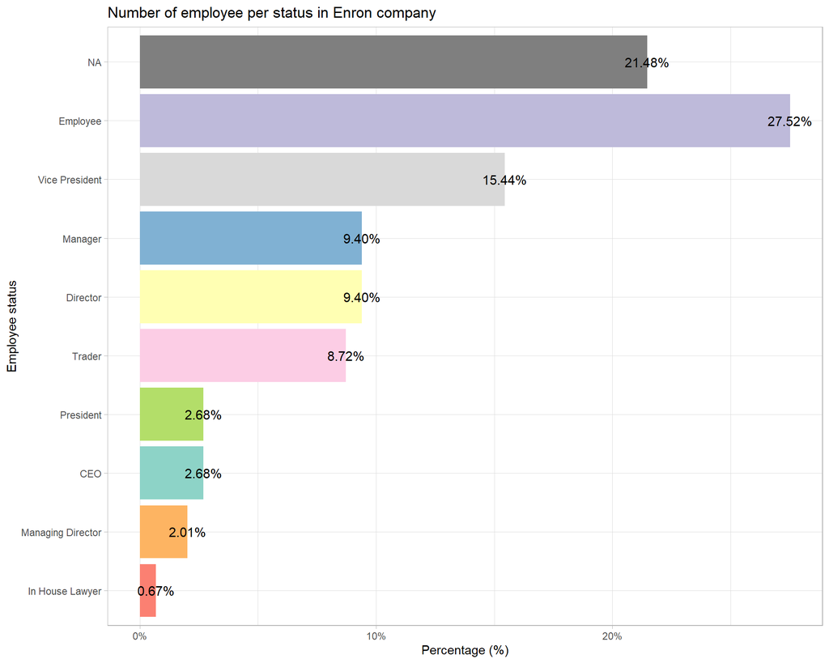

```r
employeelist_2 %>% select(status) %>% #select the needed variable
  group_by(status) %>% count() %>% #count the number of employee per status
  ungroup() %>%
  #calculate the percentage for each status
  mutate(perc = `n`/sum(`n`),
  labels = scales::percent(perc)) %>%
  #bar chart
  ggplot(aes(reorder(status, perc ,sum),perc, fill = status)) +
  geom_bar(stat = "identity") +
  #to invert the axis's position
  coord_flip()+
  #customize the theme, title and axis labels
  geom_text(aes(label = labels), vjust = 0.5, size = 4) + #display the percentage for each category at the end of the corresponding bar
  scale_y_continuous(labels = scales::percent_format())+
  ggtitle("Number of employee per status in Enron company")+
  labs(y = "Percentage (%)",x = "Employee status") +
  scale_fill_brewer(palette = "Set3",
                    #to display the NA in grey on the graph
                    na.value = "grey50"
                    )+
  theme(legend.position = "none")
```

After that we look at the email exchange in the period of study In first we extract from the date the month and year and put them into different variable.

```r
df_message_status <- df_message_status %>%
  mutate(year = format(date,"%Y"), #extract the year from the date
         month = format(date, "%m")) %>% #extract the month from the date
  transform( #to put the variable in wright type
    year = as.factor(year),
    month = as.factor(month))
```

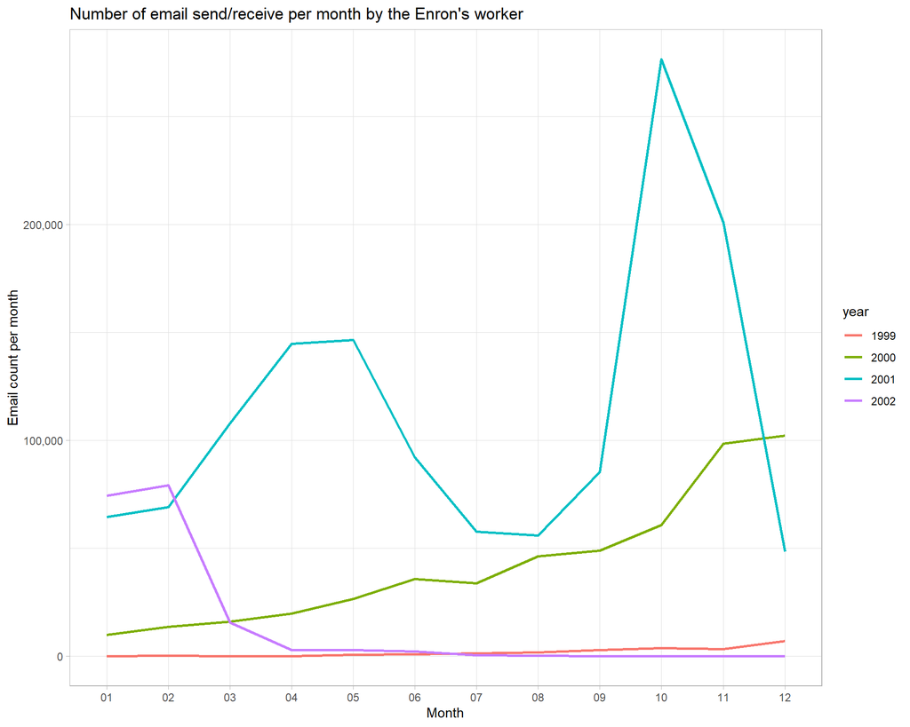

```r
df_message_status %>% group_by(year,month)%>%
  count() %>%
  ggplot(aes(month, n, group = year, color = year))+
  geom_line(size = 1)+
  scale_y_continuous(labels = scales::label_comma())+
  labs(title = "Number of email send/receive per month by the Enron's worker",
       x = "Month",
       y = "Email count per month")+
  scale_fill_brewer(palette = "Set3")
```

#### Description of the number of email send and receive

First of all in the df_message we count the distinct email address for the sender and recipient as well as often they appear in the table:

```r
#count the number of disctint sender email address
sender_count <- df_message_status %>% select(sender) %>% #keep only the variable we need
  distinct(sender) %>% #keep only once each email address
  count() #count them
```

```r
#count the number of disctint recipient email address
recipient_count <- df_message_status %>% select(recipient) %>% distinct(recipient) %>% count()
```

In the df_message table we observed that their exist 68065 different email address for receiver and 17502 different email address for sender. The important difference between them suggest one email is address to several person.

To picture in the company who is the type of Enron’s worker the most active in the email exchange we look at the number of email send and receive by each status and them compared them.

Start with the email send.

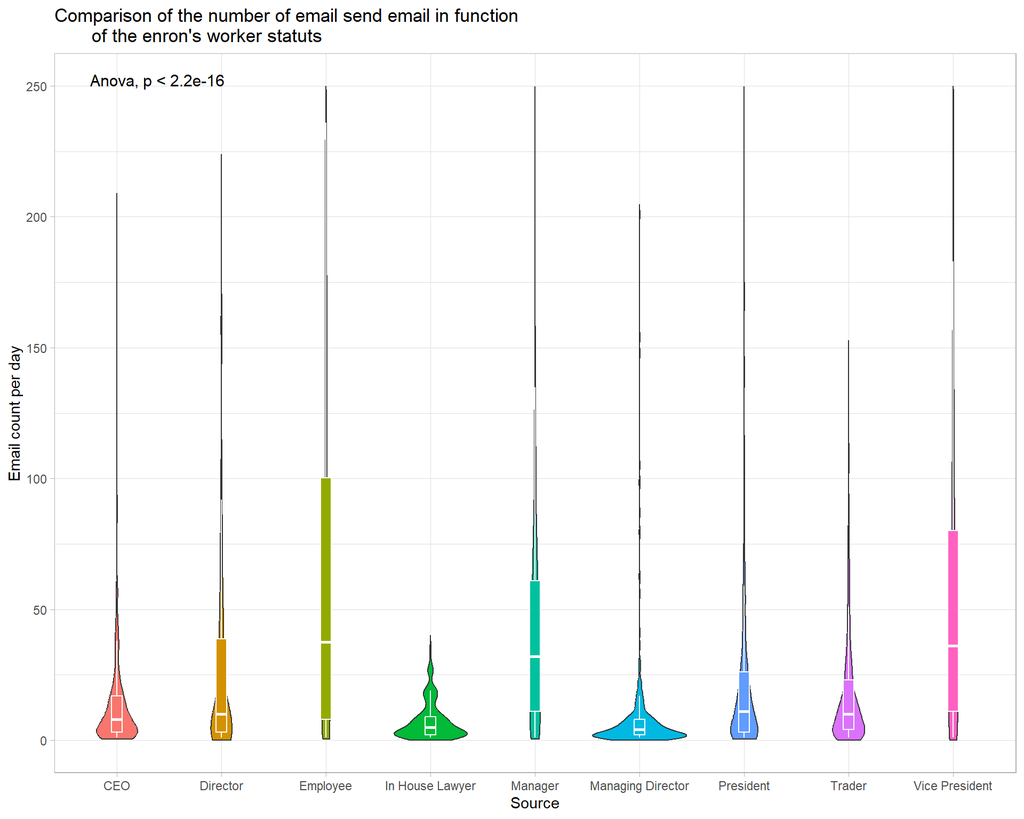

```r
#compute the number of email send per day per employee statuts
violin_worker <- df_message_status %>% filter(!is.na(status_sender)) %>%
  group_by(date, status_sender) %>%
  summarise(email_count = n(), .groups = "drop")

#violin plot
ggplot(violin_worker, aes(as.factor(status_sender), email_count, fill = as.factor(status_sender))) +
  geom_violin(trim = FALSE) +
  geom_boxplot(width = 0.1, outlier.shape = NA, color = "white")+
  ylim(c(0,250))+
  stat_compare_means(method = "anova", label.y = 250, size = 4)+
  labs(title = "Comparison of the number of email send email in function
       of the enron's worker statuts",
       x = "Source",
       y = "Email count per day") +
  theme(legend.position = "none")
```

The above plot shown us that, the employee are those who send the higher number of email in the company. The anova test show us the difference between the group is significant.

Table with the descriptive statistic for each group

```r
#descriptive statistics between the worker status group
violin_worker %>% group_by(status_sender)%>%
  summarise(
    mean = mean(email_count),
    sd = sd(email_count),
    min = min(email_count),
    Q1 = quantile(email_count, 0.25),
    Q3 = quantile(email_count, 0.75),
    max = max(email_count)
  )
```

```
## # A tibble: 9 × 7
##   status_sender       mean     sd   min    Q1    Q3   max
##   <fct>              <dbl>  <dbl> <int> <dbl> <dbl> <int>
## 1 CEO                37.7  284.       1     3  17    4740
## 2 Director           27.7   41.4      1     3  39     298
## 3 Employee          159.   271.       1    13 186.   4085
## 4 In House Lawyer     7.29   7.12     1     2   9      35
## 5 Manager            47.9   69.0      1    11  62    1044
## 6 Managing Director  10.7   32.2      1     2   8     455
## 7 President          29.6   75.5      1     3  26     988
## 8 Trader             17.6   24.0      1     4  23     307
## 9 Vice President     74.5  116.       1    12  89.8  1014
```

```r
#statistical comparison between group
pairwise.t.test(violin_worker$email_count, violin_worker$status_sender,
                #adjust the p.value with bonferroni because the number of group is small
                p.adjust.method = "bonferroni")
```

```
##
##  Pairwise comparisons using t tests with pooled SD
##
## data:  violin_worker$email_count and violin_worker$status_sender
##
##                   CEO     Director Employee In House Lawyer Manager
## Director          1.000   -        -        -               -
## Employee          < 2e-16 < 2e-16  -        -               -
## In House Lawyer   1.000   1.000    < 2e-16  -               -
## Manager           1.000   1.000    < 2e-16  0.154           -
## Managing Director 1.000   1.000    < 2e-16  1.000           0.017
## President         1.000   1.000    < 2e-16  1.000           1.000
## Trader            1.000   1.000    < 2e-16  1.000           0.032
## Vice President    0.022   7.0e-05  < 2e-16  5.7e-05         0.047
##                   Managing Director President Trader
## Director          -                 -         -
## Employee          -                 -         -
## In House Lawyer   -                 -         -
## Manager           -                 -         -
## Managing Director -                 -         -
## President         1.000             -         -
## Trader            1.000             1.000     -
## Vice President    2.5e-08           8.3e-05   2.9e-09
##
## P value adjustment method: bonferroni
```

The tables above describe the number of email send per day for each status and compared each group. This confirm the first observations shows the violin where:

- the employee are the status who send significantly the higher number of email per day in average.The Employee are also the bigger group of worker in the company. Maybe this influence the result.
- After them, it is the vice president and the manager who send the higher number of email per day. Maybe this is related to there roles in the company.

Perhaps, we pointed previously the employee is the bigger group in the Enron’s company. To confirm they are the most active group in the company in the email sending we rationalize the number of email send per day for each group in function of the number of Enron’s worker per group.

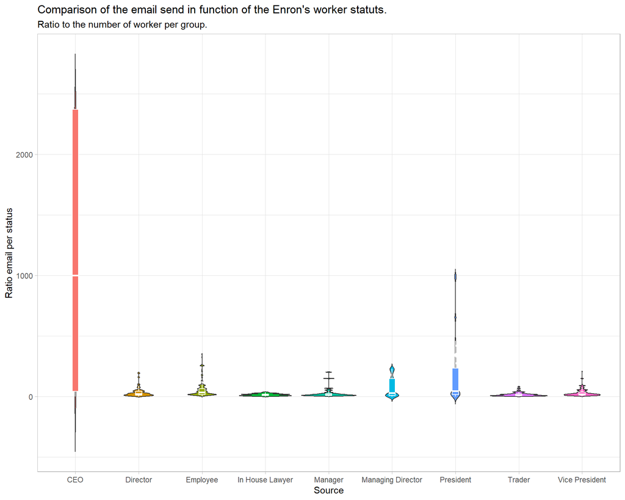

```r
#Filter to get only the worker with a knowing status
df_message_status %>% filter(!is.na(status_sender)) %>%
  group_by(date, status_sender) %>%
  #count the number of email send per day per group as well as the distinct number of worker in each group at this date
  mutate(
    nb_send = n(),#count for each group the total number of sender for a date
    nb_sender_per_gp = n_distinct(sender) #for each status count the number of different sender email address we have for a date
  ) %>% ungroup()%>%
  #made the ratio between the email send per day for each status and the number of distinct sender in that status for that day
  mutate(ratio_nb_email_pctg = nb_send/nb_sender_per_gp) %>%
  #violin box plot
  ggplot(aes(status_sender, ratio_nb_email_pctg, fill = status_sender)) +
  geom_violin(trim = FALSE)+
  geom_boxplot(width = 0.1, outlier.shape = NA, color = "white")+
  labs(title = "Comparison of the email send in function of the Enron's worker statuts.",
       subtitle = "Ratio to the number of worker per group.",
       x = "Source",
       y = "Ratio email per status")+
  theme(legend.position = "none")
```

If we rationalized the number of email send per day in function of the number it seems in general the amount of email send per day is close to 0. Maybe between 0 and 10 for the 1st quantile. Surprinsingly, it is the CEO who sent in average the higher number of email per day. Which is contradictory with what we observed previously in looking at the raw number of email per day in function of the worker status. Perhaps the violin plot suggest an important difference between the lower and the higher amount of email sent per day for them. Maybe the average is push higher because of some extreme values.

```r
df_message_status %>% filter(!is.na(status_sender)) %>%
  group_by(date, status_sender) %>% mutate(
  nb_send = n(),
  nb_sender_per_gp = n_distinct(sender)) %>% ungroup()%>%
  mutate(ratio_nb_email_pctg = nb_send/nb_sender_per_gp) %>%
  distinct(date,status_sender, sender, nb_send, nb_sender_per_gp, ratio_nb_email_pctg) %>%
  group_by(status_sender)%>% summarise(
    mean = mean(ratio_nb_email_pctg),
    median = median(ratio_nb_email_pctg),
    sd = sd(ratio_nb_email_pctg),
    min = min(ratio_nb_email_pctg),
    Q1 = quantile(ratio_nb_email_pctg, 0.25),
    Q3 = quantile(ratio_nb_email_pctg, 0.75),
    max = max(ratio_nb_email_pctg)
  )
```

```
## # A tibble: 9 × 8
##   status_sender      mean median     sd   min    Q1    Q3   max
##   <fct>             <dbl>  <dbl>  <dbl> <dbl> <dbl> <dbl> <dbl>
## 1 CEO               32.0    7    189.       1  3    15    2370
## 2 Director          12.0    7     15.6      1  3    14.5   194
## 3 Employee          23.7   16.1   25.9      1 10.7  25.7   348
## 4 In House Lawyer    7.29   5      7.12     1  2     9      35
## 5 Manager           11.3    8.43  13.0      1  5.17 13.2   201.
## 6 Managing Director  9.96   3.5   25.7      1  2     7.5   228.
## 7 President         20.3    9     59.0      1  3    18     988
## 8 Trader             7.59   5      8.03     1  2.67  9.12   81
## 9 Vice President    15.3   11.2   14.9      1  6.8  18.3   206
```

After rationalized the number of email send per worker in the group we can see that, the average of CEO is around 32 email per day with a median at 7 and the average for the employee is around 23 with a median at 16 suggesting the average for the CEO is push higher by some extreme values. Effectively, the max for the CEO is 2,370 and for the Employee it is 348. This could be the reason why the CEO seems to be the group who sent the higher number of email per day. To understand why it has this extreme value we research the date link to it.

To understand what happen we look closely to the CEO group and highlight the 10 higher values for the number of email send.

```r
df_message_status %>% filter(!is.na(status_sender)) %>%
  group_by(date, status_sender) %>% mutate(
  nb_send = n(),
  nb_sender_per_gp = n_distinct(sender)) %>% ungroup()%>%
  mutate(ratio_nb_email_pctg = nb_send/nb_sender_per_gp) %>%
  filter(status_sender == "CEO") %>%
  distinct(date,status_sender, sender, nb_send, nb_sender_per_gp, ratio_nb_email_pctg) %>%
  filter(ratio_nb_email_pctg == "2370")
```

```
## # A tibble: 2 × 6
##   date       status_sender sender   nb_send nb_sender_per_gp ratio_nb_email_pctg
##   <date>     <fct>         <chr>      <int>            <int>               <dbl>
## 1 2001-08-23 CEO           kenneth…    4740                2                2370
## 2 2001-08-23 CEO           david.w…    4740                2                2370
```

Effectively the maximum number of email send by the CEO was in August, 2001 the period where the CEO start to be worried about the risk of the fiscal fraud could be discover by the fiscal authorities.

```r
#environment cleaning
rm(jeff_stat, sender_stat, statuts_stat, p1, p2, p3, p4, violin_plot, violin_plot1, violin_plot2, violin_worker)
```

Now we look at the email received by each Enron’s worker status

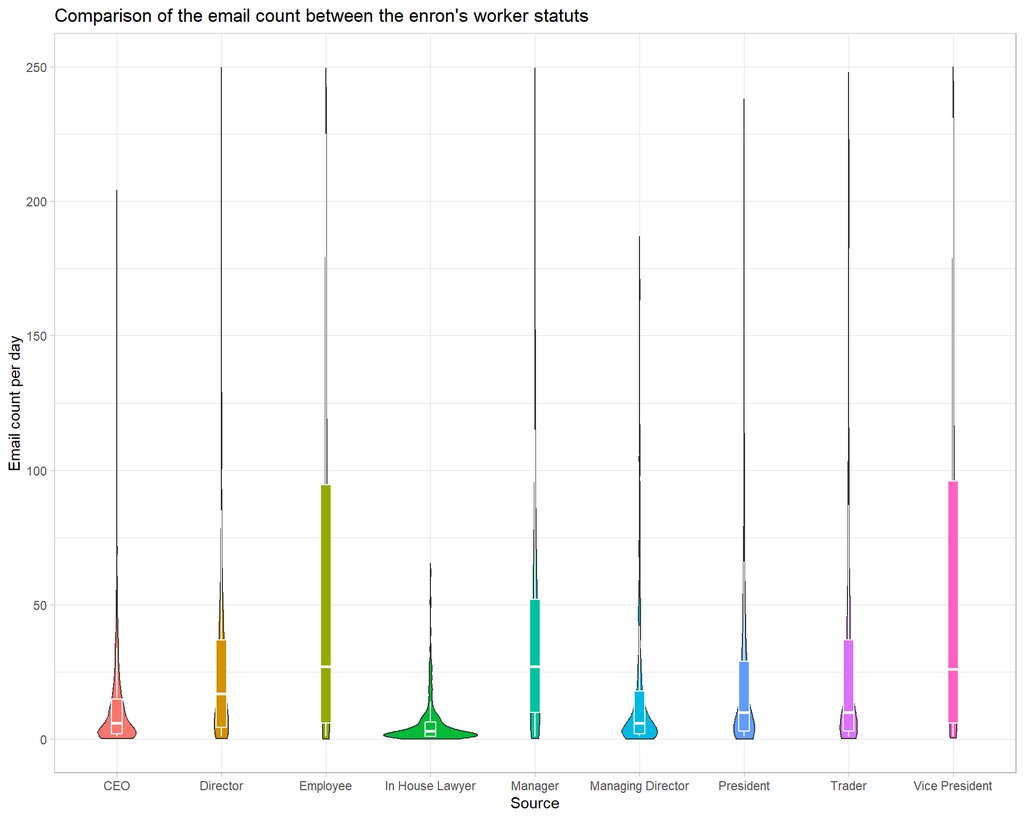

```r
#compute the number of email send per day per employee statuts
violin_worker <- df_message_status %>%   filter(!is.na(status_recipient)) %>%
  group_by(date, status_recipient) %>%
  summarise(email_count = n(), .groups = "drop")

#violin plot
ggplot(violin_worker, aes(as.factor(status_recipient), email_count, fill = as.factor(status_recipient))) +
  geom_violin(trim = FALSE) +
  geom_boxplot(width = 0.1, outlier.shape = NA, color = "white")+
  ylim(c(0,250))+
  labs(title = "Comparison of the email count between the enron's worker statuts",
       x = "Source",
       y = "Email count per day") +
  theme(legend.position = "none")
```

The employee, manager, and vice president seems to be the workers group in Enron’s company who receive the higher number of email. It seems that, the in house lawyer are those who receive the less number of email per days. The difference between group is significant.

Descriptive statistics and comparison between groups:

```r
#descriptive statistics between the worker statuts group
violin_worker %>% group_by(status_recipient)%>%
  summarise(
    mean = mean(email_count),
    median = median(email_count),
    sd = sd(email_count),
    min = min(email_count),
    Q1 = quantile(email_count, 0.25),
    Q3 = quantile(email_count, 0.75),
    max = max(email_count)
  )
```

```
## # A tibble: 9 × 8
##   status_recipient   mean median     sd   min    Q1    Q3   max
##   <fct>             <dbl>  <dbl>  <dbl> <int> <dbl> <dbl> <int>
## 1 CEO               11.6       6  15.3      1     2  15     197
## 2 Director          35.6      18  61.7      1     5  38     676
## 3 Employee          98.6      40 156.       1     7 122.   1333
## 4 In House Lawyer    5.64      3   8.14     1     1   6.5    62
## 5 Manager           42.2      28  53.1      1    10  55     438
## 6 Managing Director 18.0       6  30.4      1     2  18     178
## 7 President         22.9      10  32.4      1     3  29     224
## 8 Trader            39.8      12  70.6      1     3  42     538
## 9 Vice President    85.8      32 130.       1     7 122.   1140
```

```r
#statistical comparison between group
pairwise.t.test(violin_worker$email_count, violin_worker$status_recipient,
                #adjust the p.value with bonferroni because the number of group is small
                p.adjust.method = "bonferroni")
```

```
##
##  Pairwise comparisons using t tests with pooled SD
##
## data:  violin_worker$email_count and violin_worker$status_recipient
##
##                   CEO     Director Employee In House Lawyer Manager
## Director          9.4e-05 -        -        -               -
## Employee          < 2e-16 < 2e-16  -        -               -
## In House Lawyer   1.00000 5.9e-05  < 2e-16  -               -
## Manager           2.4e-08 1.00000  < 2e-16  8.7e-08         -
## Managing Director 1.00000 0.01940  < 2e-16  1.00000         3.3e-05
## President         0.86132 0.35860  < 2e-16  0.18185         0.00190
## Trader            9.8e-07 1.00000  < 2e-16  1.5e-06         1.00000
## Vice President    < 2e-16 < 2e-16  0.06459  < 2e-16         < 2e-16
##                   Managing Director President Trader
## Director          -                 -         -
## Employee          -                 -         -
## In House Lawyer   -                 -         -
## Manager           -                 -         -
## Managing Director -                 -         -
## President         1.00000           -         -
## Trader            0.00058           0.02020   -
## Vice President    < 2e-16           < 2e-16   < 2e-16
##
## P value adjustment method: bonferroni
```

Like for the email send we look if those result are confirm if we rationalize the number of email received per day for each group in function of the number of worker in that group.

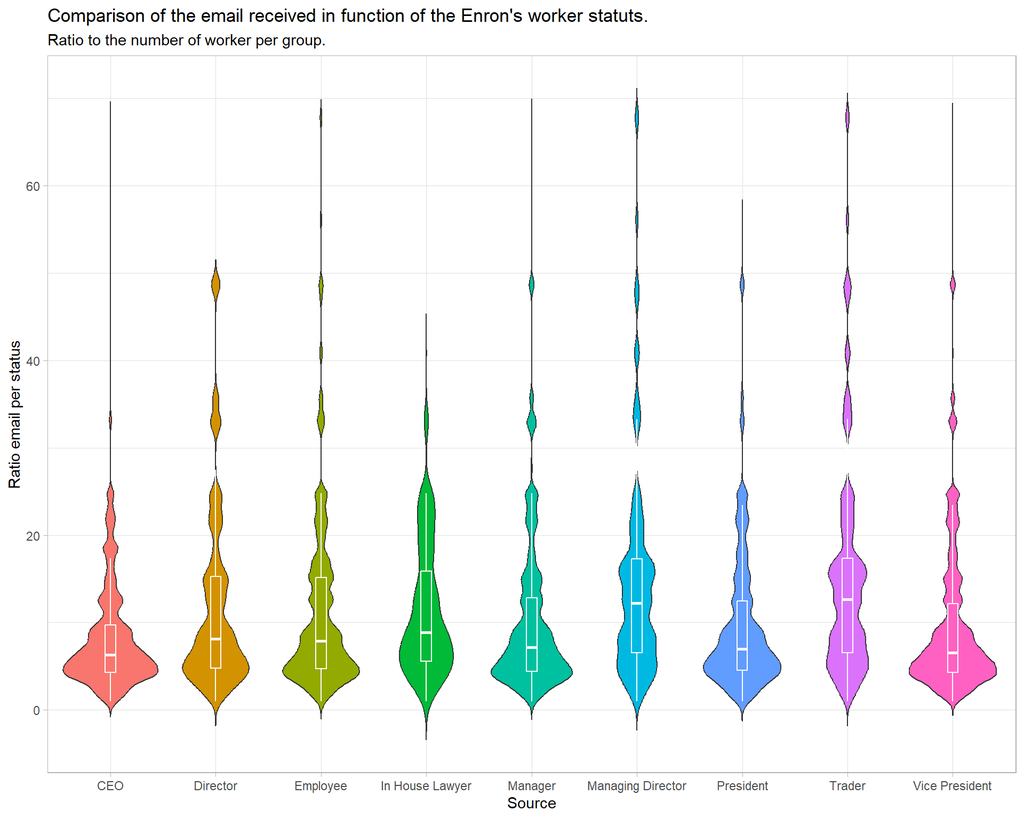

```r
#Filter to get only the worker with a knowing status
df_message_status %>% filter(!is.na(status_recipient)) %>%
  group_by(date, status_sender) %>%
  #count the number of email received per day per group as well as the distinct number of worker in each group at this date
  mutate(nb_received = n(),
  nb_received_per_gp = n_distinct(recipient)) %>%
  ungroup()%>%
  #made the ratio between the email send per day for each group and the number of worker in that group for that day
  mutate(ratio_nb_email_pctg = nb_received/nb_received_per_gp) %>%
  #violin box plot
  ggplot(aes(status_recipient, ratio_nb_email_pctg, fill = status_recipient)) +
  geom_violin(trim = FALSE)+
  geom_boxplot(width = 0.1, outlier.shape = NA, color = "white")+
  labs(title = "Comparison of the email received in function of the Enron's worker statuts.",
       subtitle = "Ratio to the number of worker per group.",
       x = "Source",
       y = "Ratio email per status")+
  theme(legend.position = "none")
```

```r
df_message_status %>% filter(!is.na(status_recipient)) %>%
  group_by(date, status_sender) %>%
  mutate(nb_received = n(),
  nb_received_per_gp = n_distinct(recipient)) %>%
  ungroup()%>%
  mutate(ratio_nb_email_pctg = nb_received/nb_received_per_gp)%>%
  #keep only distinct value
  distinct(date,status_recipient, recipient, nb_received, nb_received_per_gp, ratio_nb_email_pctg) %>%
  #make the descriptive statistics for each recipient group
  group_by(status_recipient)%>% summarise(
    mean = mean(ratio_nb_email_pctg),
    median = median(ratio_nb_email_pctg),
    sd = sd(ratio_nb_email_pctg),
    min = min(ratio_nb_email_pctg),
    Q1 = quantile(ratio_nb_email_pctg, 0.25),
    Q3 = quantile(ratio_nb_email_pctg, 0.75),
    max = max(ratio_nb_email_pctg)
  )
```

```
## # A tibble: 9 × 8
##   status_recipient   mean median    sd   min    Q1    Q3   max
##   <fct>             <dbl>  <dbl> <dbl> <dbl> <dbl> <dbl> <dbl>
## 1 CEO                5.69   4.35  5.02     1  2.86  6.52  67.8
## 2 Director           6.54   4.81  5.70     1  3.33  7.83  48.7
## 3 Employee           6.19   4.56  5.60     1  3.04  7.13  67.8
## 4 In House Lawyer    6.99   5.32  5.88     1  3.71  8.25  40.9
## 5 Manager            6.26   4.76  5.38     1  3.2   7.29  67.8
## 6 Managing Director  6.35   4.46  6.32     1  2.74  7.28  67.8
## 7 President          5.34   4.12  4.79     1  2.48  6.25  56.1
## 8 Trader             7.17   5.27  6.55     1  3.51  8.43  67.8
## 9 Vice President     5.53   4.17  4.99     1  2.67  6.41  67.8
```

If we rationalize the number of email receive by the number of worker in each group we can see they have no real different between the group. We can think that it has in each group more worker who received email than those who send them each day.

```r
#count the number of email send and recieved per day in function of their status
send_vs_received <- df_message_status %>%
  group_by(date, status_sender) %>%
  mutate(nb_sender_per_group = n_distinct(sender)) %>% ungroup()%>%
  group_by(date, status_recipient) %>%
  mutate(nb_recipient_per_group = n_distinct(recipient)) %>% ungroup()

send_vs_received <- as.data.frame(send_vs_received)

#descriptive statistic for both the sender and recipient
send_vs_received %>%
  summarise(
    across(c(nb_sender_per_group,nb_recipient_per_group),
           list(mean = ~mean(.x),
                median = ~median(.x),
                sd = ~sd(.x),
                min = ~min(.x),
                Q1 = ~quantile(.x,0.25),
                Q3 = ~quantile(.x,0.75),
                max = ~max(.x))))
```

```
##   nb_sender_per_group_mean nb_sender_per_group_median nb_sender_per_group_sd
## 1                 206.8242                        159               185.2247
##   nb_sender_per_group_min nb_sender_per_group_Q1 nb_sender_per_group_Q3
## 1                       1                     80                    281
##   nb_sender_per_group_max nb_recipient_per_group_mean
## 1                    1328                    1249.528
##   nb_recipient_per_group_median nb_recipient_per_group_sd
## 1                          1168                  849.0907
##   nb_recipient_per_group_min nb_recipient_per_group_Q1
## 1                          1                       618
##   nb_recipient_per_group_Q3 nb_recipient_per_group_max
## 1                      1930                       3156
```

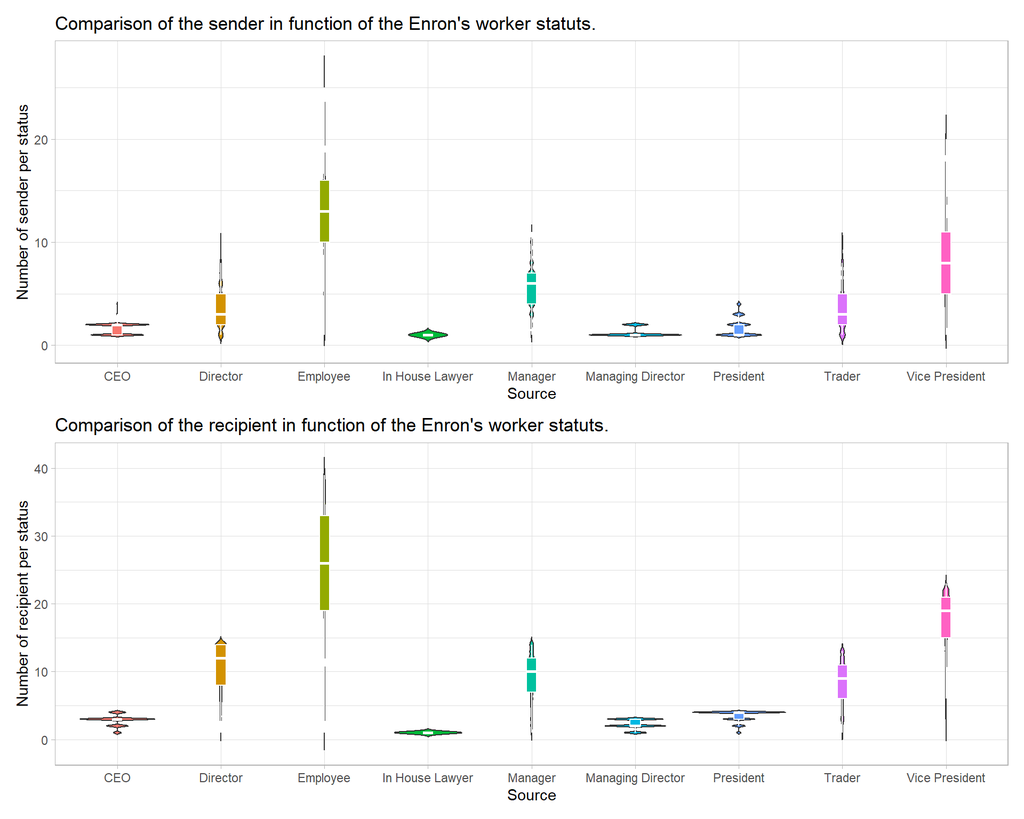

```r
#boxplot to vizualised the descriptive statistic
p1 <- send_vs_received %>% filter(!is.na(status_sender)) %>%
  ggplot(aes(status_sender, nb_sender_per_group, fill = status_sender))+
  geom_violin(trim = FALSE)+
  geom_boxplot(width = 0.1, outlier.shape = NA, color = "white")+
  labs(title = "Comparison of the sender in function of the Enron's worker statuts.",
       x = "Source",
       y = "Number of sender per status")+
  theme(legend.position = "none")

p2 <- send_vs_received %>% filter(!is.na(status_recipient)) %>%
  ggplot(aes(status_recipient, nb_recipient_per_group, fill = status_recipient))+
  geom_violin(trim = FALSE)+
  geom_boxplot(width = 0.1, outlier.shape = NA, color = "white")+
  labs(title = "Comparison of the recipient in function of the Enron's worker statuts.",
       x = "Source",
       y = "Number of recipient per status")+
  theme(legend.position = "none")

p1/p2
```

We can see that, it as in average more person in a group who receive email each day compared to the number of person who send them. This is especially true for the worker in the employee, trader, vice president, and director groups.

**From all of those we can deduce that, it seems the most active Enron’s worker int the email exchange is Jeff Dasovitch. In general it is the employee who are the more active in email exchange. When we rationalize the number of email sent in function of the number of worker per group we could see that, the employee are really the more active for sending email but at some point the CEO group send a high number of email due to the Enron’s events. If we look at the number of email receive in function of the number of worker in a group we see no real different between the group suggesting it as more person who receive email each day than person who send them.**

Next we take a look at the flux of the email exchange between the different status over the study period to see if it change.

We now look if along the year it as a change in the interaction between the Enron’s worker with a knowing status. For that per year we draw chord diagram which allows to follow the links between group.

```r
#plot for each year follow the exchange between group
per_year <- df_message_status %>% select(date, status_sender, status_recipient) %>%
  filter(!is.na(status_sender) & !is.na(status_recipient)) %>%
  mutate(year = format(date,"%Y"),
         #to enhance the clarity we group certain status with similar level of responsability together
         status_sender = case_when(
           status_sender %in% c("Managing Director", "Manager", "Director") ~ "Manger - Director",
           status_sender %in% c("CEO", "Vice President", "President") ~ "CEO - President",
           .default = status_sender),
         status_recipient = case_when(
           status_recipient %in% c("Managing Director", "Manager", "Director") ~ "Manger - Director",
           status_recipient %in% c("CEO", "Vice President", "President") ~ "CEO - President",
           .default = status_recipient)) %>%
  group_by(date,status_sender, status_recipient) %>%
  mutate(number_exchange = n()) %>% ungroup() %>%
  distinct(date, status_sender, status_recipient, number_exchange, year)

year_1999 <- as.data.frame(per_year %>% filter(year == 1999) %>%
  group_by(status_sender, status_recipient) %>%
  mutate(sum = sum(number_exchange)) %>% ungroup() %>%
  distinct(status_sender, status_recipient, sum) %>%
    filter(status_sender != status_recipient) %>%
    arrange(status_sender, status_recipient)
)

year_2000 <- as.data.frame(per_year %>% filter(year == 2000) %>%
  group_by(status_sender, status_recipient) %>%
  mutate(sum = sum(number_exchange)) %>% ungroup() %>%
  distinct(status_sender, status_recipient, sum) %>%
    filter(status_sender != status_recipient) %>%
    arrange(status_sender, status_recipient)
)

year_2001 <- as.data.frame(per_year %>% filter(year == 2001) %>%
  group_by(status_sender, status_recipient) %>%
  mutate(sum = sum(number_exchange)) %>% ungroup() %>%
  distinct(status_sender, status_recipient, sum) %>%
    filter(status_sender != status_recipient) %>%
    arrange(status_sender, status_recipient)
)

year_2002 <- as.data.frame(per_year %>% filter(year == 2002) %>%
  group_by(status_sender, status_recipient) %>%
  mutate(sum = sum(number_exchange)) %>% ungroup() %>%
  distinct(status_sender, status_recipient, sum) %>%
    filter(status_sender != status_recipient) %>%
    arrange(status_sender, status_recipient)
)

#the color for each status
status_color <- c(
  "Employee" = "pink",
  "CEO - President" = "orange",
  "Trader" = "springgreen3",
  "Manger - Director" = "violetred4",
  "In House Lawyer" = "purple4")
```

Display the chord diagram of the year 1999

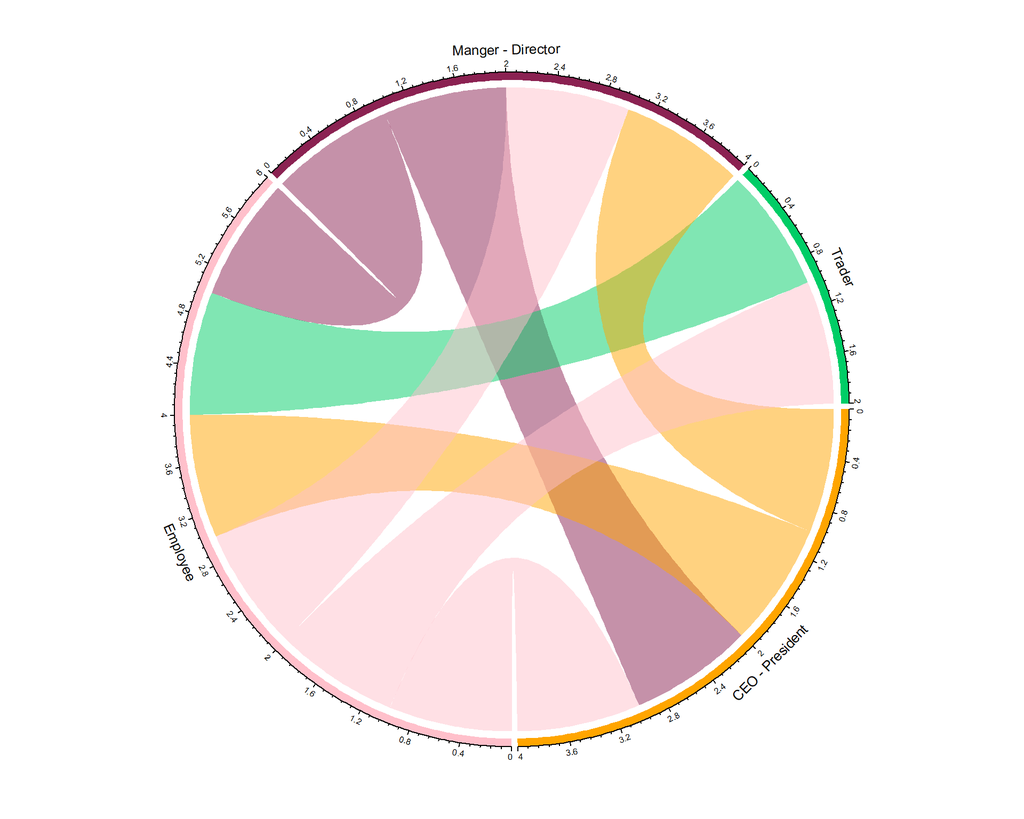

```r
adjacencyData_99 <-with(year_1999, table(status_sender, status_recipient))
chordDiagram(adjacencyData_99, transparency = 0.5, grid.col = status_color)
```

year 2000

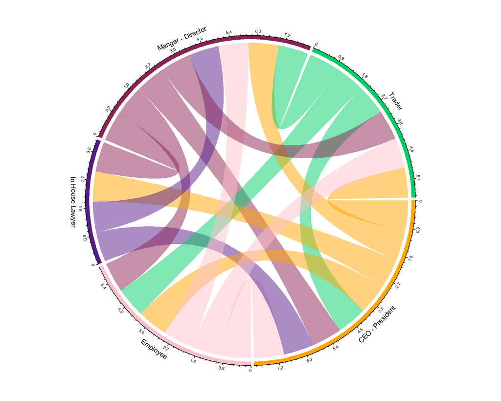

```r
adjacencyData_00 <-with(year_2000, table(status_sender, status_recipient))
chordDiagram(adjacencyData_00, transparency = 0.5, grid.col = status_color)
```

year 2001

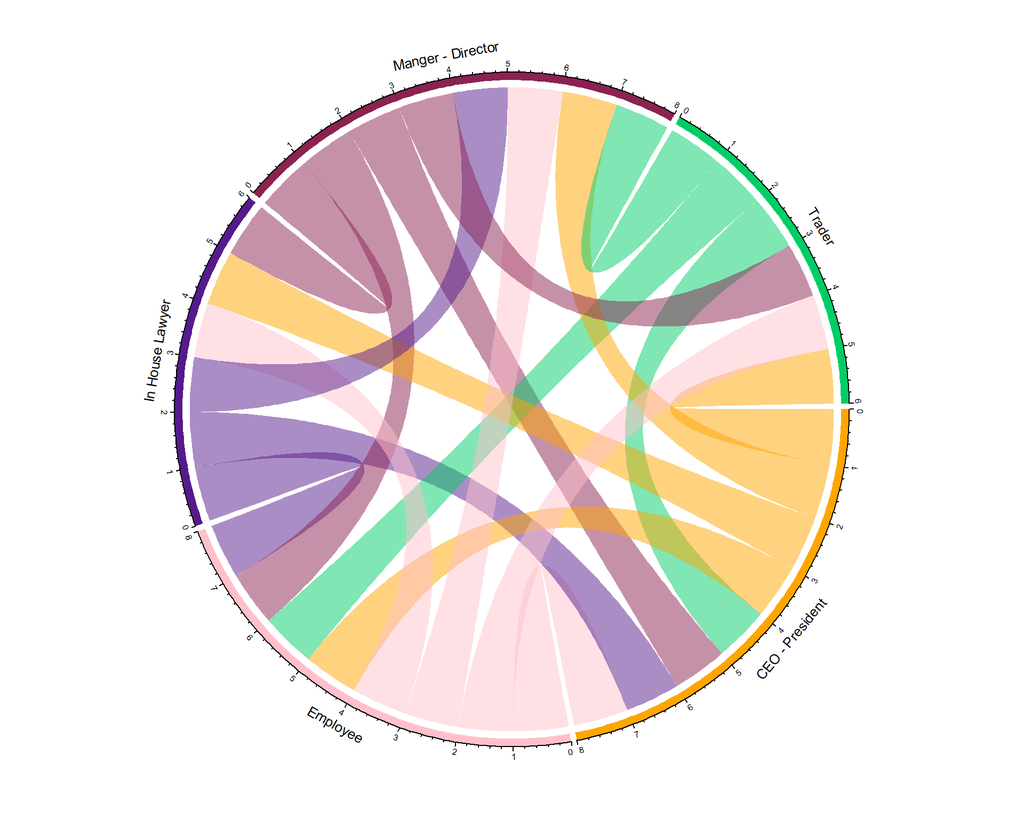

```r
adjacencyData_01 <-with(year_2001, table(status_sender, status_recipient))
chordDiagram(adjacencyData_01, transparency = 0.5, grid.col = status_color)
```

year 2002

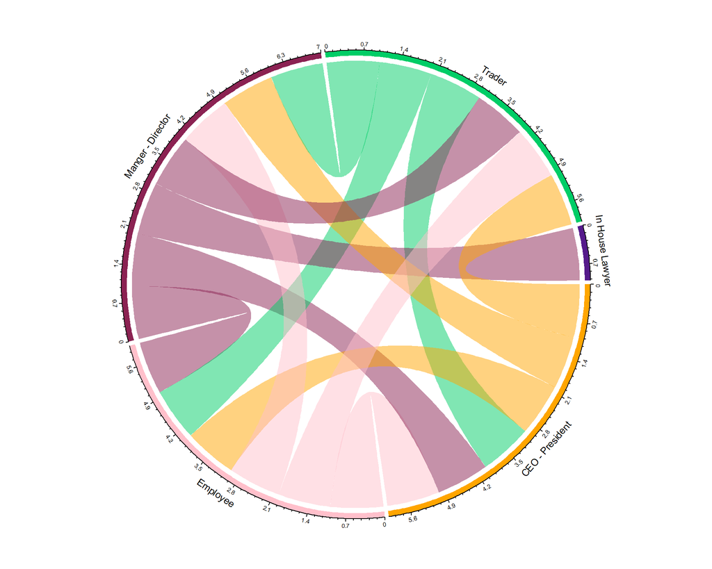

```r
adjacencyData_02 <-with(year_2002, table(status_sender, status_recipient))
chordDiagram(adjacencyData_02, transparency = 0.5, grid.col = status_color)
```

For the email exchange we can see that:

- The trader in 1999 exchange only with employee but then they exchange also with manager/director and CEO/president. Surprinsigly it seems the trader never exchange with the in house lawyer. Maybe their email exchange are undirect.
- In 2002 the in house lawyer have received emain only from the manager/director. But at this period, we don’t see the email flux from the in house lawyer to other worker in the company with a knowing status. Maybe they send email to external person for managing the bankruptcy of the company with the info they received from the manager and director.
- The in house Lawyer exchange in 2000 only with the manager/director and the CEO/President but in 2001 they also exchange with employee. Maybe the change in the email flux for the in house lawyer is related to the Enron event where it could have a need to inform the employee about some affair for they can answer to the SEC investigations.

**This last analyze highlight the change in the email flux over the study period. Some change could be linked with the Enron event.**

##### The number of email send/receive per month over the year.

The data set we have cover the email exchange between Enron’s worker from 1999 to 2002. From 1999 to early 2001 the company was in good health. From the midle of 2001 the fraud made by the company start to become public and put the company in trouble. Through the email history we will look if over the months it as a change for the number of email send/receive in function of the worker status.

We look over the month of each year which are the worker status the most active. For the employee.

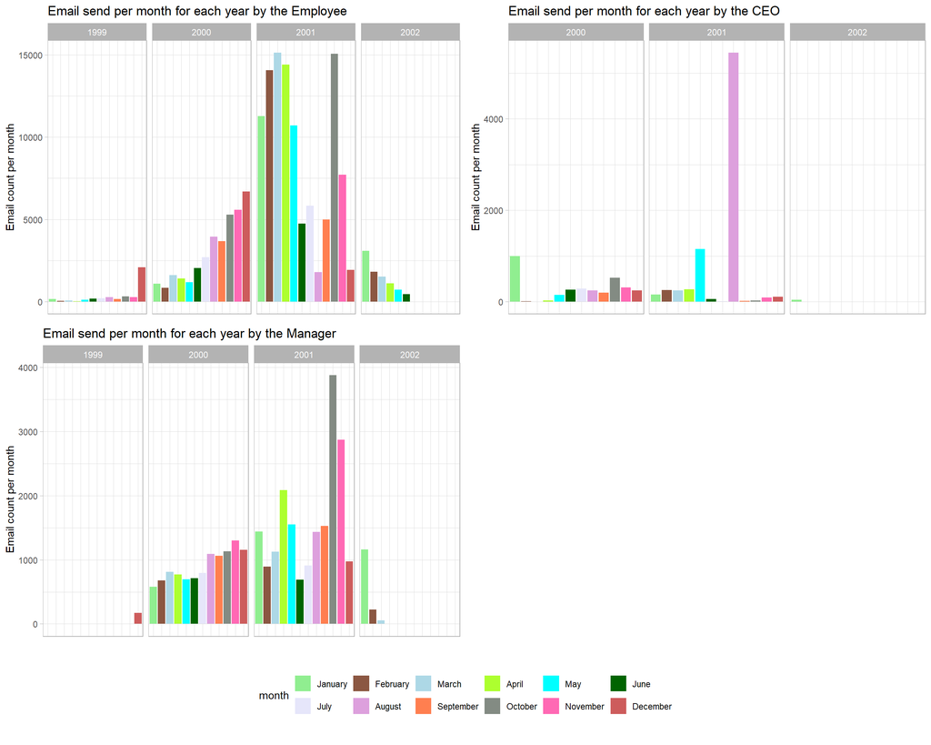

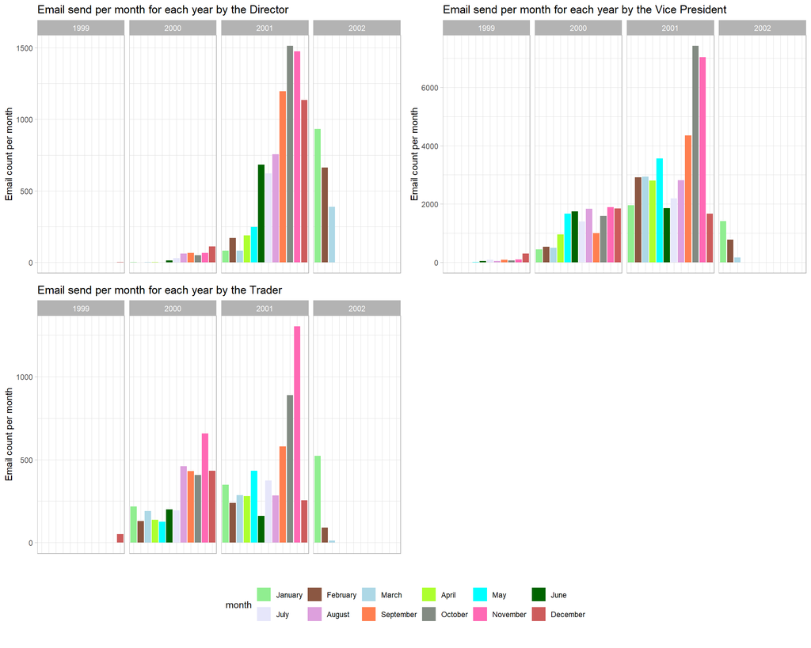

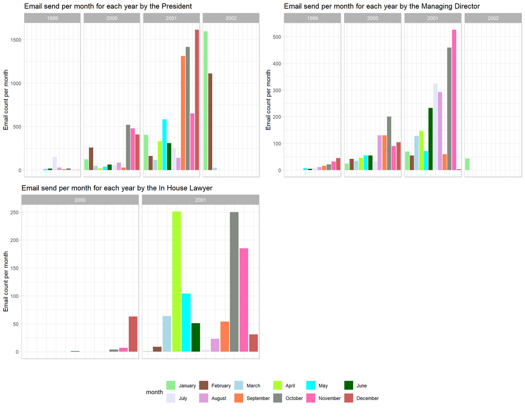

```r
#list of status in the Enron company
status_list <- c("Employee", "CEO", "Manager", "Director", "Vice President", "Trader", "President", "Managing Director", "In House Lawyer")

month_label <- c("01" = "January","02" = "February","03" = "March","04" = "April","05" = "May","06" = "June","07" = "July","08" = "August",
               "09" = "September","10" = "October","11" = "November","12" = "December")

month_color <- c("01" = "lightgreen","02" = "lightsalmon4","03" = "lightblue","04" = "greenyellow","05" = "cyan","06" = "darkgreen","07" = "lavender",
               "08" = "plum","09" = "coral","10" = "honeydew4","11" = "hotpink","12" = "indianred")

#initiate the list for the plot
email_send <- list()

#loop allowing to construct a bar plot to display per month the number of email send in function of the worker status
for(i in seq(status_list)){

  status <- status_list[i]

  p <- df_message_status %>% filter(status_sender == status) %>% #take the value in the list
  group_by(year,month)%>%
  count() %>%
    #bar plot
    ggplot(aes(month, n, fill = month))+
  geom_bar(stat = "identity") +
  facet_grid(~year)+
  labs(title = paste("Email send per month for each year by the", status),
       y = "Email count per month")+
  scale_fill_manual(
    values = month_color,
    labels = month_label)+
  theme(legend.position = "bottom",
        axis.text.x = element_blank(),
        axis.ticks.x = element_blank(),
        axis.title.x = element_blank())

  email_send[[i]] <- p}

#display the plot create
n <- length(email_send)

plot_per_section <- 3

for(j in seq(1,n,by=plot_per_section)){

  plot_on_the_page <- email_send[j:min(j+2, n)]

  #extract the legend from the first plot on the layout
  legend <- get_legend(plot_on_the_page[[1]], nrow = 2)

  #remove the legend for all plot on the layout
  no_legend <- lapply(plot_on_the_page, function(p) p + theme(legend.position = "none"))

  #display 4 plots per layout
  grid_plot <- arrangeGrob(grobs = no_legend, ncol = 2)

  #combine together the 3 plot and one legend
  plots_with_legend <- arrangeGrob(
    grid_plot,
    legend,
    nrow = 2,
    #arrange the plot and the legend in the layout
    heights = unit.c(unit(1,"npc") - unit(7, "lines"), unit(7,"lines"))
  )

  #display everything together
  grid.newpage()
  grid.draw(plots_with_legend)

}
```

Now we look for the email receive in function of the Enron’s worker status.

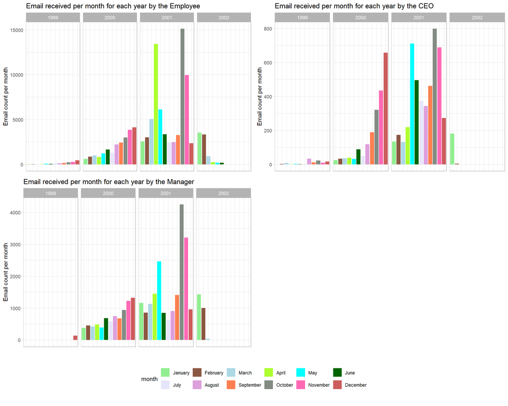

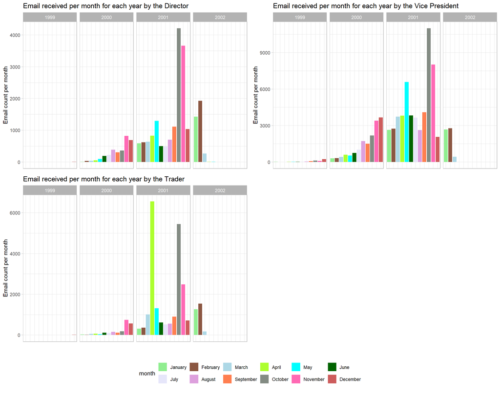

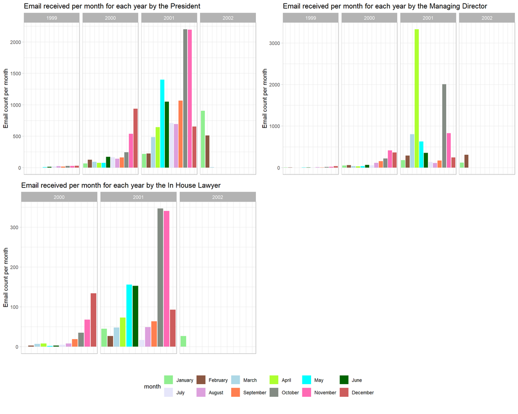

```r
#initiate the list for the plot
email_received <- list()

#loop allowing to construct a bar plot to display per month the number of email send in function of the worker status
for(i in seq(status_list)){

  status <- status_list[i]

  p <- df_message_status %>% filter(status_recipient == status) %>% #take the value in the list
  group_by(year,month)%>%
  count() %>%
    #bar plot
    ggplot(aes(month, n, fill = month))+
  geom_bar(stat = "identity") +
  facet_grid(~year)+
  labs(title = paste("Email received per month for each year by the", status),
       y = "Email count per month")+
  scale_fill_manual(
    values = month_color,
    labels = month_label)+
  theme(legend.position = "bottom",
        axis.text.x = element_blank(),
        axis.ticks.x = element_blank(),
        axis.title.x = element_blank())

  email_received[[i]] <- p}

#display the plot create
n <- length(email_received)

plot_per_section <- 3

for(j in seq(1,n,by=plot_per_section)){

  plot_on_the_page <- email_received[j:min(j+2, n)]

  #extract the legend from the first plot on the layout
  legend <- get_legend(plot_on_the_page[[1]], nrow = 2)

  #remove the legend for all plot on the layout
  no_legend <- lapply(plot_on_the_page, function(p) p + theme(legend.position = "none"))

  #display 4 plots per layout
  grid_plot <- arrangeGrob(grobs = no_legend, ncol = 2)

  #combine together the 3 plot and one legend
  plots_with_legend <- arrangeGrob(
    grid_plot,
    legend,
    nrow = 2,
    #arrange the plot and the legend in the layout
    heights = unit.c(unit(1,"npc") - unit(7, "lines"), unit(7,"lines"))
  )

  #display everything together
  grid.newpage()
  grid.draw(plots_with_legend)

}
```

The plot above shows that:

- Like for the email send, it is the employee who receive the higher number. They follow the same trend as we saw for the email send suggesting they are active in email exchange in general.
- The trader seems to received more email than sending them.
- For the group at the head of the company (CEO, Managing director, director, president and vice president) the number of email receive follow the Enron’s fiscal fraud event with a high pick in 2001 for the months April, May, October, and November.
- For the year 2001, the vice president group receive a lot of email compared to the other head group of the company.
- It is for the year 2001 the group in house lawyer seems to receive the higher number of email.

```r
#envrionment cleaning
rm(jeff_stat, recipient_stat, statuts_stat, violin_plot, violin_plot1, violin_plot2, violin_worker, p1, p2, send_vs_received)
```

Now we try to see who is the most active in the email exchange. For that, we start by counting the number of email send per each worker and return the 10 persons who send the highest number.

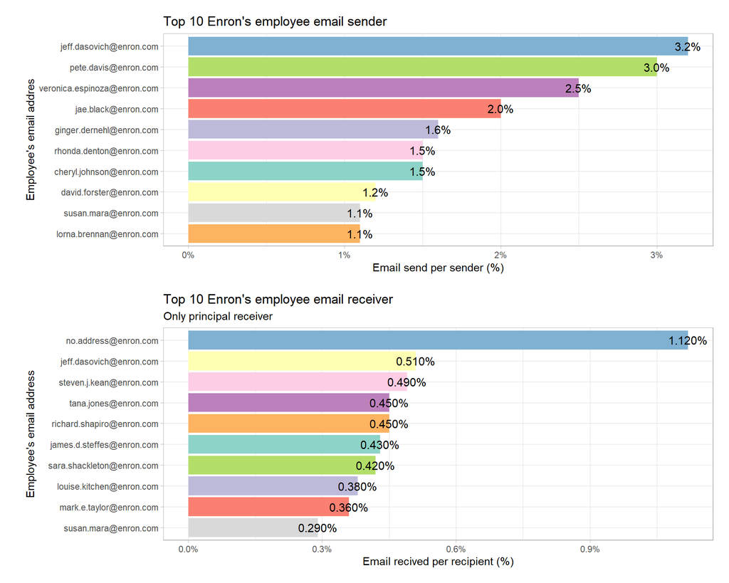

```r
#Display the top 10 email address of sender
p1 <- df_message_status %>% group_by(sender)%>% count() %>% #to count the number of email send per email address
  ungroup() %>%
  #calculate the percentage for each sender
  mutate(perc = round(`n`/sum(`n`),3),
  labels = scales::percent(perc)) %>%
  arrange(desc(n)) %>% head(10) %>% #to get only the 10 email address with the most important number of email send
  #bar chart
  ggplot(aes(reorder(sender, perc, sum), perc, fill = sender)) +
  geom_bar(stat="identity") +
  coord_flip() +
  #graph title and label
  geom_text(aes(label = labels), vjust = 0.5, size = 4) + #display the percentage for each category at the end of the corresponding bar
  scale_y_continuous(labels = scales::percent_format())+
  labs(title = "Top 10 Enron's employee email sender")+
  xlab("Employee's email addres")+
  ylab("Email send per sender (%)") +
  scale_fill_brewer(palette = "Set3")+
    theme(legend.position = "none",
        plot.margin = margin(10, 10, 10, 20))

#Display the top 10 email address of recipient
p2 <- df_message_status %>% filter(rtype == "TO") %>% #select only the email of the direct concerned receiver
  group_by(recipient)%>% count() %>% #to count the number of email send per email address
  ungroup() %>%
  #calculate the percentage for each sender
  mutate(perc = round(`n`/sum(`n`),4),
  labels = scales::percent(perc)) %>%
  arrange(desc(n)) %>% head(10) %>% #to get only the 10 email address with the most important number of email send
  #bar chart
  ggplot(aes(reorder(recipient, perc, sum), perc, fill = recipient)) +
  geom_bar(stat="identity") +
  coord_flip() +
  #graph title and label
  geom_text(aes(label = labels), vjust = 0.5, size = 4) + #display the percentage for each category at the end of the corresponding bar
  scale_y_continuous(labels = scales::percent_format())+
  labs(title = "Top 10 Enron's employee email receiver",
       subtitle = "Only principal receiver")+
  xlab("Employee's email address")+
  ylab("Email recived per recipient (%)") +
  scale_fill_brewer(palette = "Set3")+
  theme(legend.position = "none",
        plot.margin = margin(10, 10, 10, 20))

#arrange the plot on the same place
p1 / p2
```

```r
#return only one result from that query to get the status of the most active sender/recipient
head(df_message_status[df_message_status$sender == "jeff.dasovich@enron.com", "status_sender"],
     n=1)
```

```
## [1] Employee
## 10 Levels: CEO Director Employee In House Lawyer Manager ... Vice President
```

In the employee data set he is described to be an Employee of Enron. To see if it is really the most active we will compared the number of email send and received by him to the other worker with the same status (Employee) and to all the worker of Enron company.

For that we will compute descriptive comparative statistic between them.

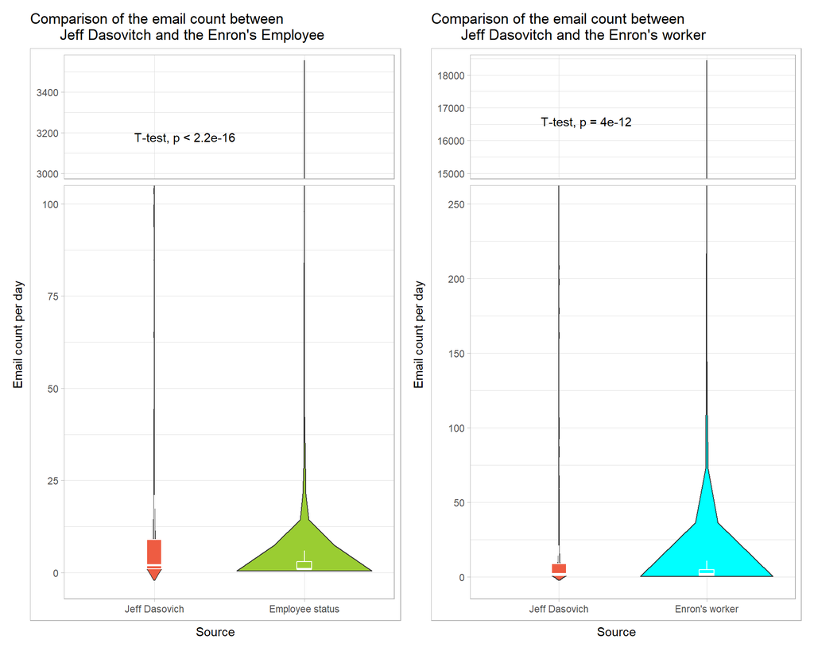

```r
#count the number of email send by jeff dasovich per day
jeff_stat_send <- df_message_status %>% filter(sender == "jeff.dasovich@enron.com") %>%
  #we count the number of different email subject send per day
  group_by(date, subject) %>%
  summarise(email_count = n(), .groups = "drop") %>%
  mutate(source = "Jeff Dasovich") %>% transform(source = as.factor(source))

#count the number of email send by Enron's worker per day
sender_stat <- df_message_status %>%
  #we count the number of different email subject send per day by each sender
  group_by(date, sender, subject) %>%
  summarise(email_count = n(), .groups = "drop") %>%
  mutate(source = "Enron's worker") %>% select(-sender) %>% transform(source = as.factor(source))

#count the number of email send by Employee status per day
statuts_stat_send <- df_message_status %>% filter(status_sender == "Employee") %>%
  #we count the number of different email subject send per day by each sender of status employee
  group_by(date, sender, subject) %>%
  summarise(email_count = n(), .groups = "drop") %>%
  mutate(source = "Employee status") %>% transform(source = as.factor(source))

#combine the rows together to create a unique dataframe and compared the enron's worker and the employee to Jeff
violin_plot1 <- bind_rows(jeff_stat_send, statuts_stat_send)
violin_plot2 <- bind_rows(jeff_stat_send, sender_stat)

#compared the 2 groups per a t.test to see if jeff dasovitch is really most active than the other employee
p3 <- ggplot(violin_plot1, aes(as.factor(source), email_count, fill = as.factor(source))) +
  geom_violin(trim = FALSE) +
  geom_boxplot(width = 0.1, outlier.shape = NA, color = "white")+
  #display the comparative statistic on the violin plot
  stat_compare_means(method = "t.test", label.y = max(violin_plot1$email_count) - 400)+
  labs(title = "Comparison of the email count between
       Jeff Dasovitch and the Enron's Employee",
       x = "Source",
       y = "Email count per day") +
  #to better see the violin plot we break the y axis
  scale_y_break(c(100, 3000), scales = 0.3)+
  #set up the color for each resources
  scale_fill_manual(values = c(
      "Jeff Dasovich" = "tomato2",
      "Employee status" = "yellowgreen"))+
  #withdraw the legend form the plot
  theme(legend.position = "none")

#same plot but to compared Jeff Dasovitch to the Enron's worker
p4 <- ggplot(violin_plot2, aes(as.factor(source), email_count, fill = as.factor(source))) +
  geom_violin(trim = FALSE) +
  geom_boxplot(width = 0.1, outlier.shape = NA, color = "white")+
  stat_compare_means(method = "t.test", label.y = max(violin_plot2$email_count) - 2000)+
  scale_y_break(c(250, 15000), scales = 0.3)+
  labs(title = "Comparison of the email count between
       Jeff Dasovitch and the Enron's worker",
       x = "Source",
       y = "Email count per day") +
  scale_fill_manual(#set up the color for each resources
    values = c(
      "Jeff Dasovich" = "tomato2",
      "Enron's worker" = "cyan"))+
  theme(legend.position = "none")

#arrange the plot on the same place
p3 + p4
```

```r
#display the stat of the different group
violin_plot <- bind_rows(jeff_stat_send, sender_stat, statuts_stat_send)

violin_plot %>% group_by(source)%>%
  summarise(
    mean = mean(email_count),
    sd = sd(email_count),
    min = min(email_count),
    Q1 = quantile(email_count, 0.25),
    Q3 = quantile(email_count, 0.75),
    max = max(email_count)
  )
```

```
## # A tibble: 3 × 7
##   source           mean    sd   min    Q1    Q3   max
##   <fct>           <dbl> <dbl> <int> <dbl> <dbl> <int>
## 1 Jeff Dasovich   15.6   45.7     1     1     9   760
## 2 Enron's worker  10.6   80.6     1     1     5 18445
## 3 Employee status  5.49  29.9     1     1     3  3556
```

The table who summarise the email send by group show us that:

- It is Jeff Dasovitch who have the highest average for the number of email sent per day. The lowest is for the Enron’s employee.
- By looking at the quantile, which represent respectively the 25% of the value and the 75% of the value, it is also Jeff who have the highest value for the quantile 3 especialy compared to the Enron’s Employee.
- Surprinsingly it is the Enron’s worker who have the highest number of email send for a day. Maybe that is link with the Enron event.

*From this we can deduce that, Jeff Dasovitch is significantly the most active Enron’s worker in the email sending.*

Then we look at the email recieved by Jeff Dasovitch compared to Enron’s worker of the same status and to all Enron’s worker.

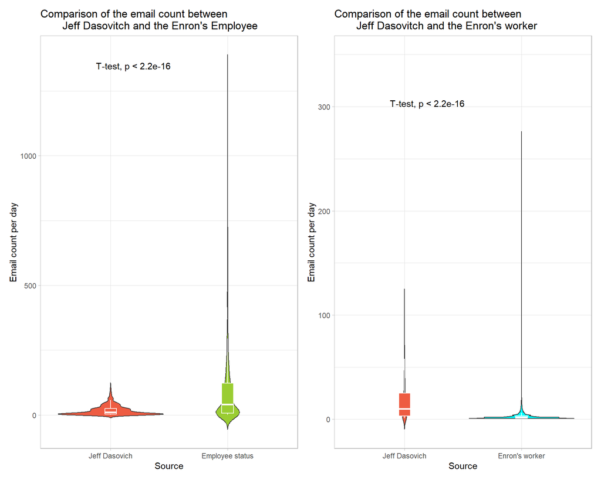

```r
#statistics on the jeff dasovich email receive per day
jeff_stat_rec <- df_message_status %>% filter(recipient == "jeff.dasovich@enron.com") %>%
  group_by(date) %>%
  summarise(email_count = n(), .groups = "drop") %>%
  mutate(source = "Jeff Dasovich") %>% transform(source = as.factor(source))

#statistics on the email send per day by the enron's worker
recipient_stat <- df_message_status %>% group_by(date, recipient) %>%
  summarise(email_count = n(), .groups = "drop") %>%
  mutate(source = "Enron's worker") %>% select(-recipient) %>% transform(source = as.factor(source))

#statistics on the email send per day by the enron's worker who have an employee statuts
statuts_stat_rec <- df_message_status %>% filter(status_recipient == "Employee") %>% group_by(date) %>%
  summarise(email_count = n(), .groups = "drop") %>%
  mutate(source = "Employee status") %>% transform(source = as.factor(source))

#combine the rows together to create a unique dataframe and compared the enron's worker and the employee to Jeff
violin_plot1 <- bind_rows(jeff_stat_rec, statuts_stat_rec)
violin_plot2 <- bind_rows(jeff_stat_rec, recipient_stat)

#compared the 2 groups per a t.test to see if jeff dasovitch is really most active than the other employee and/or worker in Enron's company
p3 <- ggplot(violin_plot1, aes(as.factor(source), email_count, fill = as.factor(source))) +
  geom_violin(trim = FALSE) +
  geom_boxplot(width = 0.1, outlier.shape = NA, color = "white")+
  #compared statisticaly the 2 group to see if the difference is significant or not
  stat_compare_means(method = "t.test", label.y = max(violin_plot1$email_count) + 2)+
  labs(title = "Comparison of the email count between
       Jeff Dasovitch and the Enron's Employee",
       x = "Source",
       y = "Email count per day") +
  theme(legend.position = "none")+
  scale_fill_manual(#set up the color for each resources
    values = c(
      "Jeff Dasovich" = "tomato2",
      "Employee status" = "yellowgreen"
    ))

p4 <- ggplot(violin_plot2, aes(as.factor(source), email_count, fill = as.factor(source))) +
  geom_violin(trim = FALSE) +
  geom_boxplot(width = 0.1, outlier.shape = NA, color = "white")+
  ylim(c(-10,350))+
  stat_compare_means(method = "t.test", label.y = 300)+
  labs(title = "Comparison of the email count between
       Jeff Dasovitch and the Enron's worker",
       x = "Source",
       y = "Email count per day") +
  theme(legend.position = "none")+
  scale_fill_manual(#set up the color for each resources
    values = c(
      "Jeff Dasovich" = "tomato2",
      "Enron's worker" = "cyan"
    ))

#arrange the plot on the same place
p3 + p4
```

```r
violin_plot <- bind_rows(jeff_stat_rec, recipient_stat, statuts_stat_rec)

violin_plot %>% group_by(source) %>%
  summarise(
    mean = mean(email_count),
    median = median(email_count),
    sd = sd(email_count),
    min = min(email_count),
    Q1 = quantile(email_count, 0.25),
    Q3 = quantile(email_count, 0.75),
    max = max(email_count)
  )
```

```
## # A tibble: 3 × 8
##   source           mean median     sd   min    Q1    Q3   max
##   <fct>           <dbl>  <dbl>  <dbl> <int> <dbl> <dbl> <int>
## 1 Jeff Dasovich   17.5      10  19.2      1     3   25    113
## 2 Enron's worker   3.19      2   6.36     1     1    3   1153
## 3 Employee status 98.6      40 156.       1     7  122.  1333
```

When we look at the number of email received, Jeff Dasovich received significantly more email than another Enron’s worker in average. Perhaps, when we compared him to the other employee he don’t recived more email compared to another employee. On the contrary, it significantly received less than other. For the Enron’s worker with an employee status we observed that, the mean is far from the median suggesting it exist extreme value for that group. The violin of the employee highlight that where we can see above the 3rd quantile it as a long queue which start around 120 to become extremely thin after 250. On the contrary for Jeff Dasovich violin above the 3rd quantile the violin queue isn’t become finer but it seems to always has an important number of observation with this values. All of those suggest that for the employee it has some event which made them received an extremely high number of email, this pick isn’t see for Jeff Dasovich.

**From this part of the analyze we can say that:**

**- Compared to other worker with an employee it significantly send more email but it received less.**

**- it is possible that, it has some events whose made other employee than Jeff Dasovich receiving more email in one day. We could thing Jeff Dasovich is one of the employee who receive the most email per day but not the only one.**

**All of those suggest that, Jeff Dasovich could be the most active employee to send email.**

### Analyze of the email subject and content

In our data set the number of email exchange for which we have 2063706 rows with content which represent 10%. This make the email content few exhaustive compared to the email subject which is describe for every email exchange. For this reason we will in first look at the subject which match with the pattern research and then look at the key words in the email content.

We create 4 list which are related of 4 different topics which will be research in the email subject:

- email related to meeting by looking to words such as message, please, email, inform.
- email related to the business processes and business legalities such as enron, deal, change, corp, date, america
- email related to the core business of Enron like gas, power, trade.

From the Enron’s scandal wikipedia page we take some words which we expect ot find in the email content we have. Those word are related with the enron event. source: [wikipedia page about Enron timeline downfall](https://en.wikipedia.org/wiki/Enron_scandal#Timeline_of_downfall). We research:

*mark-to-market which is related to the way they process to do the fiscal fraud

*10-K which is the name of their annual financial report publish in Texas Journal and push some person to invest in the Enron company

*losing money because in august 2001 an anlyste asking how Enron company can lose a lot of money after wining a lot.

*SEC investigation where in mid-October 2001 the investigation by the SEC start to invest suspicious deals.

*fears an emotion who is regularly wrote in the wikipedia article to describing the feeling of the investor as well as the employee of Enron after October 2001

*correction since October 2001, the enron company start a process of correction on their revenue. We research this word in the email content and the subject.

*bankruptcy to see from which date they start to speak of it.

Each word/concept will be research individually in the email content to follow the email exchange whose contain them as well as the Enron’s worker status imply in those exchange.

The analyze is realized over the study period to highlight period where those topics/key words are more used by the enron worker. Then we will look if it has worker status who used them more than other to finally look at some specific enron worker know to be involved in the Enron’s events.

#### Research of the 4th topics in the email subjects as well as key word in email content.

```r
#topics list

topic_meeting <- c("message|origin|pleas|email|thank|attach|file|copi|inform|receiv|thank|all|time|meet|look|week|day|dont|vinc|talk")

topic_business_process <- c("enron|deal|agreement|chang|contract|corp|fax|houston|date|america|risk|analy|confidential|correction")

topic_core_business <- c("market|gas|price|power|company|energy|trade|busi|servic|manag")

topic_enron_event <- c("bankrup|SEC|MTM|fear")
```

```r
#construction of the data set for measuring the frequency of the different topic in the email subject as well as the number of email with specific word, we focus on the sender status

email_subject <- df_message_status %>% distinct(date, sender, status_sender, subject, reference) %>%
  mutate(#count the number of email which contain at least one word in the list of each topic
    topic_meeting = if_else(str_detect(subject, topic_meeting), 1, 0),
    topic_business_process = if_else(str_detect(subject, topic_business_process), 1, 0),
    topic_core_business = if_else(str_detect(subject, topic_core_business), 1, 0),
    topic_enron_event = if_else(str_detect(subject, topic_enron_event), 1, 0),
    email_mark_to_market = if_else(str_detect(reference,"mark-to-market"), 1, 0),
    email_10K_report = if_else(str_detect(reference, "10-K"), 1, 0),
    email_losing_money = if_else(str_detect(reference, "losing money"), 1, 0),
    email_SEC_investigation = if_else(str_detect(reference, "SEC"), 1, 0),
    email_fear_feeling = if_else(str_detect(reference, "fears"), 1, 0),
    email_correction = if_else(str_detect(reference,"correction"),1,0),
    email_bankruptcy = if_else(str_detect(reference, "bankruptcy"), 1, 0),
    year = format(date, "%Y"),
    month=format(date,"%m"),
    #to get the date in year/month
    year_month = as.Date(paste0(year,"-",month,"-01"))) %>%
  #compute the sum of each topics for each month of each year study
  group_by(year_month) %>%
  mutate(
    sum_topic_meeting = sum(topic_meeting),
    sum_topic_business_process = sum(topic_business_process),
    sum_topic_core_business = sum(topic_core_business),
    sum_topic_enron_event = sum(topic_enron_event),
    #for the email we use na.rm = TRUE to allow the sum to be done
    sum_email_mark_to_market = sum(email_mark_to_market, na.rm = TRUE),
    sum_email_10K_report = sum(email_10K_report, na.rm = TRUE),
    sum_email_losing_money = sum(email_losing_money, na.rm = TRUE),
    sum_email_SEC_investigation = sum(email_SEC_investigation, na.rm = TRUE),
    sum_email_fear_feeling = sum(email_fear_feeling, na.rm = TRUE),
    sum_email_correction = sum(email_correction, na.rm = TRUE),
    sum_email_bankruptcy = sum(email_bankruptcy, na.rm = TRUE)
    ) %>% ungroup() %>%
  #keep one line per year and month
  distinct(year_month, sum_topic_meeting, sum_topic_business_process, sum_topic_core_business, sum_topic_enron_event, sum_email_mark_to_market,
    sum_email_10K_report,
    sum_email_losing_money,
    sum_email_SEC_investigation,
    sum_email_fear_feeling,
    sum_email_correction,
    sum_email_bankruptcy)
```

Because the number of line which contain email description is lower than the length of the table the research of the keyword about Enron event in the email create many NA value. To be able to compute the sum of the email which contain those word we use the parameter na.rm = TRUE which consider the NA as it is a 0 in the data set to compute the sum.

In the following part we will create plot which will represent the email exchange about specific topics. To homogenized the apparence of those plot we declared a color and a label for each category for they can be apply at every plot.

```r
#the list of category studied and their related color in each plot
topic_colors <- c("sum_email_SEC_investigation" = "darkred",
                                      "sum_email_10K_report" = "pink",
                                      "sum_email_bankruptcy" = "darkgreen",
                                      "sum_email_correction" = "orange",
                                      "sum_email_mark_to_market" = "lavender",
                                      "sum_email_losing_money" = "turquoise",
                                      "sum_email_fear_feeling" = "darkblue",
                                      "sum_topic_business_process" = "blue",
                                      "sum_topic_core_business" = "gold",
                                      "sum_topic_meeting" = "chocolate",
                  "sum_topic_enron_event" = "yellowgreen")



#the list of category and their related label on the plot
topic_label <- c("sum_email_SEC_investigation" = "SEC Investigation email",
                               "sum_email_10K_report" = "10-K report email",
                               "sum_email_bankruptcy" = "Bankruptcy email",
                               "sum_email_correction" = "Correction email",
                               "sum_email_mark_to_market" = "mark-to-market process email",
                               "sum_email_losing_money" = "Losing money email",
                               "sum_email_fear_feeling" = "Fear feeling email",
                               "sum_topic_business_process" = "Business process email topic",
                               "sum_topic_core_business" = "Core Business email topic",
                               "sum_topic_meeting" = "Meeting email topic",
                 "sum_topic_enron_event" = "Enron Event")
```

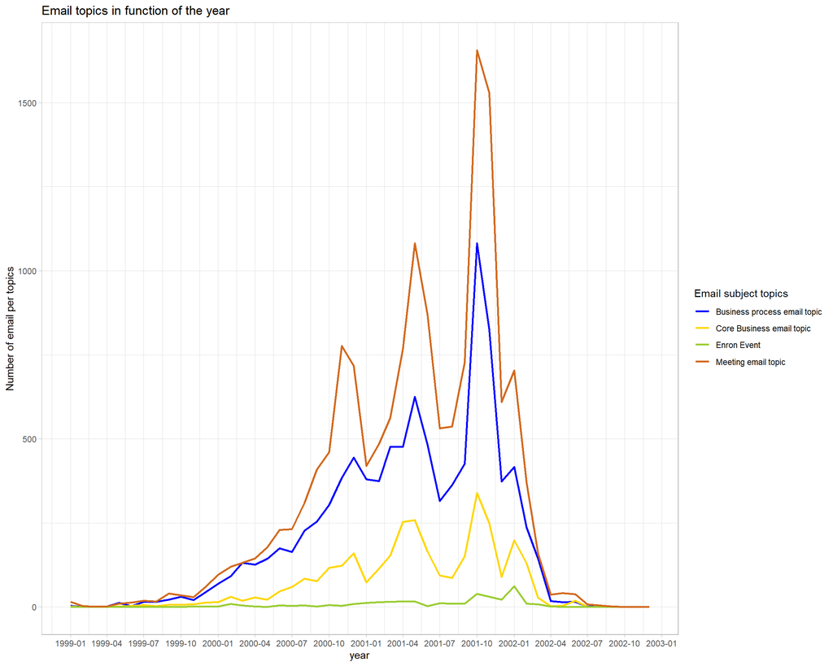

```r
#display the different topic trend in the email subject over the study's period
email_subject %>% select(year_month, starts_with("sum_topic_")) %>%
  #change the orientation of the data set
  pivot_longer(
  cols = 2:5,
  names_to = "topics",
  values_to = "value") %>%
  #scatter plot and trend line
  ggplot(aes(year_month,value, color=topics))+
  geom_line(size = 1)+
  #label, axis, and legend
  labs(color = "Email subject topics",
    title = "Email topics in function of the year",
       x = "year",
       y = "Number of email per topics") +
  #to display the year and month, every 3 months for a better reading
  scale_x_date(date_labels = "%Y-%m", date_breaks = "3 months")+
  scale_color_manual(#to get only the customization for the email categories
    values = topic_colors[8:11],
    labels = topic_label[8:11])
```

We can see that:

- the top topic is about the meeting then we have the business process and the business core.
- For the meeting we have 3 picks:
  - one between October, 2000 and January, 2001 maybe to organize the new year and close the past year.
  - one April to July, 2001 which is the period where the head of the company start to be worry about the business process.
  - the highest pick is between October 2001 and January, 2002 the period where the fiscal fraud is discover by the federal agency.
  - For the business process and core topics we see 2 picks which follows the 2 last picks of the meeting topics. This suggest the topic of the meeting concern the business. We could think those meeting are more related to the business process than the business core.

  -The email about the enron event are the fewest but we can see a pick of the topic from October 2001 to average February 2002. This make sens with the knowing event where the company was put in bankruptcy at this period.

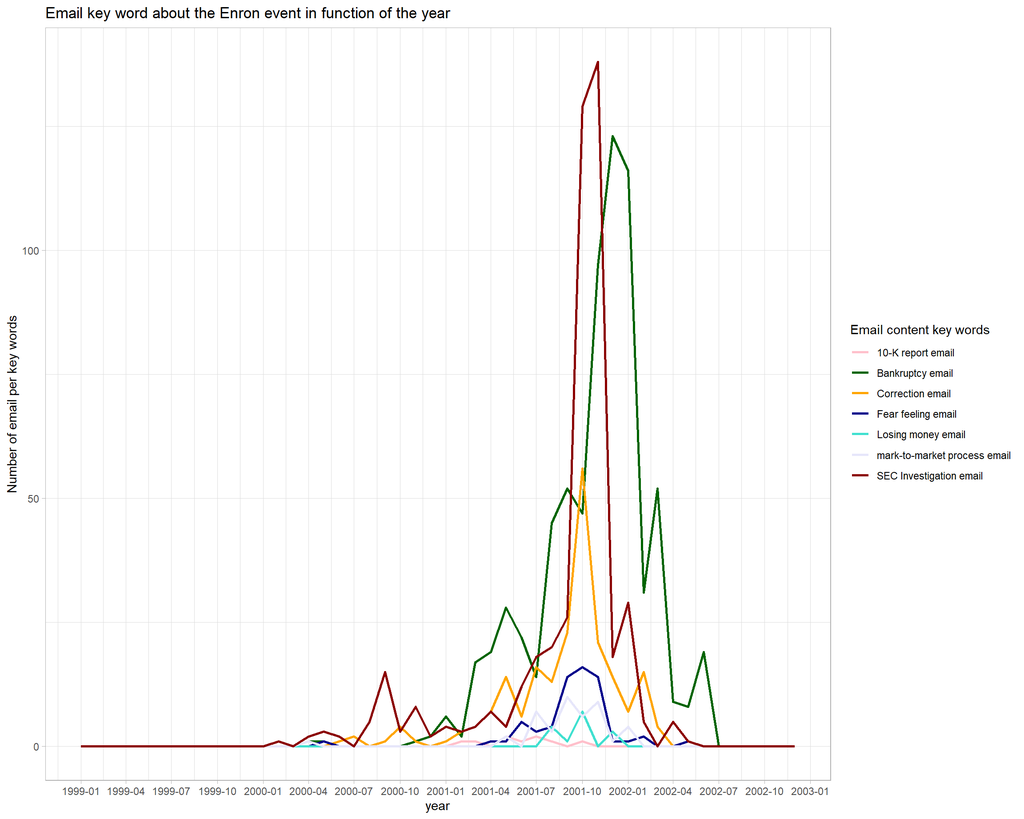

```r
#display the different topic trend in the email subject over the study's period
email_subject %>% select(year_month, starts_with("sum_email_")) %>%
  #change the orientation of the data set
  pivot_longer(
  cols = 2:8,
  names_to = "email",
  values_to = "value") %>%
  #scatter plot and trend line
  ggplot(aes(year_month,value, color=email))+
  geom_line(size = 1)+
  #label, axis, and legend
  labs(color = "Email content key words",
    title = "Email key word about the Enron event in function of the year",
       x = "year",
       y = "Number of email per key words") +
  #to display the year and month, every 3 months for a better reading
  scale_x_date(date_labels = "%Y-%m", date_breaks = "3 months")+
  scale_color_manual(#to get only the customization for the email categories
    values = topic_colors[1:7],
    labels = topic_label[1:7])
```

The graph above shows us that:

- the email speaking about the mark-to-market process, losing money by the company, and the 10-K report represent the lowest number of email.
- the top key words we can see in the email are bankruptcy and SEC investigation.
- it start to have exchange about the SEC investigation between July and October 2000 which is follow exchange about a bankruptcy between January and July 2001.
- The most important number of exchange about the SEC investigation are realized between July 20001 and January 2002. In parallel we saw also an important number of exchange about a bankruptcy for the company. Compared to the number of email subject who speak about the bankruptcy it as more email content who speak to it. This suggest this topic was a little hidden.
- At the pick of exchange about SEC investigation and bankruptcy we saw email exchange containing fear feeling as well as exchange about financial correction.

We pursue by looking for each email subject topics and email key words which type of Enron’s worker status are the more active.

For that we create a similar data frame than the previous but by making the count of topics/email in function of the employee status

```r
status_email_subject <- df_message_status %>% distinct(date, sender, status_sender, subject, reference) %>%
  mutate(#count the number of email which contain at least one word in the list of each topic
    topic_meeting = if_else(str_detect(subject, topic_meeting), 1, 0),
    topic_business_process = if_else(str_detect(subject, topic_business_process), 1, 0),
    topic_core_business = if_else(str_detect(subject, topic_core_business), 1, 0),
    topic_enron_event = if_else(str_detect(subject, topic_enron_event), 1, 0),
    email_mark_to_market = if_else(str_detect(reference,"mark-to-market"), 1, 0),
    email_10K_report = if_else(str_detect(reference, "10-K"), 1, 0),
    email_losing_money = if_else(str_detect(reference, "losing money"), 1, 0),
    email_SEC_investigation = if_else(str_detect(reference, "SEC"), 1, 0),
    email_fear_feeling = if_else(str_detect(reference, "fears"), 1, 0),
    email_correction = if_else(str_detect(reference,"correction"),1,0),
    email_bankruptcy = if_else(str_detect(reference, "bankruptcy"), 1, 0),
    year = format(date, "%Y")) %>%
  #we focus on the worker which their status are know
  filter(!is.na(status_sender)) %>%
  #compute the sum of each topics for each year studied
  group_by(year, status_sender) %>%
  mutate(
    sum_topic_meeting = sum(topic_meeting),
    sum_topic_business_process = sum(topic_business_process),
    sum_topic_core_business = sum(topic_core_business),
    sum_topic_enron_event = sum(topic_enron_event),
    #for the email we use na.rm = TRUE to allow the sum to be done
    sum_email_mark_to_market = sum(email_mark_to_market, na.rm = TRUE),
    sum_email_10K_report = sum(email_10K_report, na.rm = TRUE),
    sum_email_losing_money = sum(email_losing_money, na.rm = TRUE),
    sum_email_SEC_investigation = sum(email_SEC_investigation, na.rm = TRUE),
    sum_email_fear_feeling = sum(email_fear_feeling, na.rm = TRUE),
    sum_email_correction = sum(email_correction, na.rm = TRUE),
    sum_email_bankruptcy = sum(email_bankruptcy, na.rm = TRUE)
    ) %>% ungroup() %>%
  #keep one line per year and month
  distinct(year, status_sender, sum_topic_meeting, sum_topic_business_process, sum_topic_core_business, sum_topic_enron_event, sum_email_mark_to_market,
    sum_email_10K_report,
    sum_email_losing_money,
    sum_email_SEC_investigation,
    sum_email_fear_feeling,
    sum_email_correction,
    sum_email_bankruptcy)

#pivot the data frame
status_email_subject <- status_email_subject %>%
  pivot_longer(
    cols = 3:length(status_email_subject),
    names_to = "topic_email",
    values_to = "value")
```